# Numpy Reminders:

# Time Shifting

Sometimes you may need to shift all your data up or down along the time series index. In fact, a lot of pandas built-in methods do this under the hood. This isn't something we'll do often in the course, but it's definitely good to know about this anyways!

```python
df = pd.read_csv('./original/TSA_COURSE_NOTEBOOKS/Data/starbucks.csv',index_col='Date',parse_dates=True)
```

## .shift() forward

This method shifts the entire date index a given number of rows, without regard for time periods (months & years).  
It returns a modified copy of the original DataFrame.

In other words, it moves down all the rows down or up.

```python
# We move down all the rows
df.shift(1).head()
```

| Date | Close | Volume |
| --- | --- | --- |
| 2015-01-02 | NaN | NaN |
| 2015-01-05 | 38.0061 | 6906098.0 |
| 2015-01-06 | 37.2781 | 11623796.0 |
| 2015-01-07 | 36.9748 | 7664340.0 |
| 2015-01-08 | 37.8848 | 9732554.0 |

```python
# NOTE: You will lose that last piece of data that no longer has an index!
df.shift(1).tail()
```

| Date | Close | Volume |
| --- | --- | --- |
| 2018-12-24 | 61.39 | 23524888.0 |
| 2018-12-26 | 60.56 | 6323252.0 |
| 2018-12-27 | 63.08 | 16646238.0 |
| 2018-12-28 | 63.20 | 11308081.0 |
| 2018-12-31 | 63.39 | 7712127.0 |

## Shifting based on Time Series Frequency Code

We can choose to shift *index values* up or down without realigning the data by passing in a **freq** argument.  
This method shifts dates to the next period based on a frequency code. Common codes are 'M' for month-end and 'A' for year-end.  
Refer to the *Time Series Offset Aliases* table from the Time Resampling lecture for a full list of values, or click [here](http://pandas.pydata.org/pandas-docs/stable/user_guide/timeseries.html#offset-aliases).

```python
# Shift everything to the end of the month
df.shift(periods=1, freq='M').head()
```

| Date | Close | Volume |
| --- | --- | --- |
| 2015-01-31 | 38.0061 | 6906098 |
| 2015-01-31 | 37.2781 | 11623796 |
| 2015-01-31 | 36.9748 | 7664340 |
| 2015-01-31 | 37.8848 | 9732554 |
| 2015-01-31 | 38.4961 | 13170548 |

For more info on time shifting visit http://pandas.pydata.org/pandas-docs/stable/generated/pandas.DataFrame.shift.html

# Rolling and Expanding

A common process with time series is to create data based off of a rolling mean. The idea is to divide the data into "windows" of time, and then calculate an aggregate function for each window. In this way we obtain a *simple moving average*. Let's show how to do this easily with pandas!

```python
df = pd.read_csv('./original/TSA_COURSE_NOTEBOOKS/Data/starbucks.csv', index_col='Date', parse_dates=True)
```

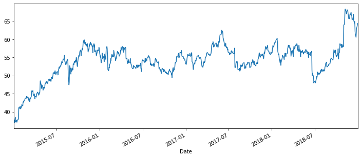

```python
df['Close'].plot(figsize=(12,5)).autoscale(axis='x',tight=True);
```

Now let's add in a rolling mean! This rolling method provides row entries, where every entry is then representative of the window.

```python
# 7 day rolling mean
df.rolling(window=7).mean().head(15)
```

| Date | Close | Volume |
| --- | --- | --- |
| 2015-01-02 | NaN | NaN |
| 2015-01-05 | NaN | NaN |
| 2015-01-06 | NaN | NaN |
| 2015-01-07 | NaN | NaN |
| 2015-01-08 | NaN | NaN |
| 2015-01-09 | NaN | NaN |
| 2015-01-12 | 37.616786 | 1.238222e+07 |
| 2015-01-13 | 37.578786 | 1.297288e+07 |
| 2015-01-14 | 37.614786 | 1.264020e+07 |
| 2015-01-15 | 37.638114 | 1.270624e+07 |
| 2015-01-16 | 37.600114 | 1.260380e+07 |
| 2015-01-20 | 37.515786 | 1.225634e+07 |
| 2015-01-21 | 37.615786 | 9.868837e+06 |
| 2015-01-22 | 37.783114 | 1.185335e+07 |
| 2015-01-23 | 38.273129 | 1.571999e+07 |

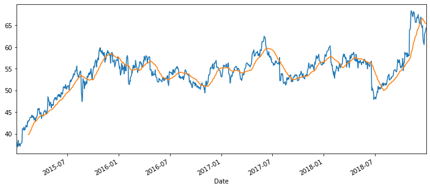

```python
df['Close'].plot(figsize=(12,5)).autoscale(axis='x',tight=True)
df.rolling(window=30).mean()['Close'].plot();
```

## Expanding

Instead of calculating values for a rolling window of dates, what if you wanted to take into account everything from the start of the time series up to each point in time? For example, instead of considering the average over the last 7 days, we would consider all prior data in our expanding set of averages.

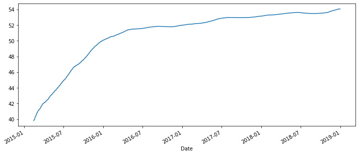

```python
# Optional: specify a minimum number of periods to start from
df['Close'].expanding(min_periods=30).mean().plot(figsize=(12,5));
```

# Visualizing Time Series Data

```python
df = pd.read_csv('./original/TSA_COURSE_NOTEBOOKS/Data/starbucks.csv',index_col='Date',parse_dates=True)
```

First we'll create a line plot that puts both `'Close'` and `'Volume'` on the same graph.  
Remember that we can use `df.plot()` in place of `df.plot.line()`

```python
df.index = pd.to_datetime(df.index)
```

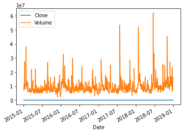

```python
df.plot();
```

## Adding a title and axis labels

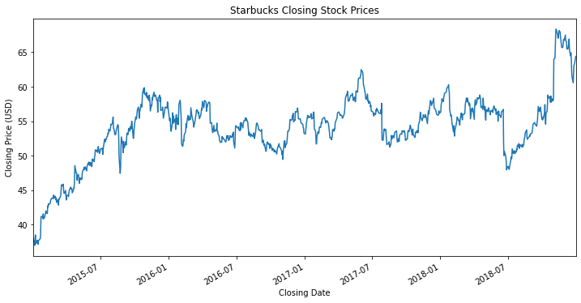

```python
title='Starbucks Closing Stock Prices'
ylabel='Closing Price (USD)'
xlabel='Closing Date'

ax = df['Close'].plot(figsize=(12,6),title=title)
ax.autoscale(axis='x',tight=True)
ax.set(xlabel=xlabel, ylabel=ylabel);
```

Thanks to the date index, we can make a selection like the following:

```python
df['Close']['2017-01-01':'2017-03-01']
```

```
Date
2017-01-03    53.1100
2017-01-04    53.7241
2017-01-05    54.1750
2017-01-06    54.8179
2017-01-09    55.8446
2017-01-10    55.5376
2017-01-11    55.7487
2017-01-12    55.6815
2017-01-13    55.5088
2017-01-17    55.6527
2017-01-18    56.0845
2017-01-19    55.5472
2017-01-20    55.3265
2017-01-23    55.4224
2017-01-24    56.0749
2017-01-25    56.3244
2017-01-26    56.0941
2017-01-27    53.8488
2017-01-30    53.6377
2017-01-31    52.9852
2017-02-01    51.7186
2017-02-02    51.6899
2017-02-03    52.8317
2017-02-06    53.4746
2017-02-07    53.2433
2017-02-08    53.2240
2017-02-09    53.7927
2017-02-10    54.1878
2017-02-13    54.0818
2017-02-14    54.5348
2017-02-15    54.8047
2017-02-16    54.6794
2017-02-17    55.2770
2017-02-21    55.4601
2017-02-22    55.4890
2017-02-23    55.5565
2017-02-24    55.4023
2017-02-27    54.7276
2017-02-28    54.8143
2017-03-01    55.0746
Name: Close, dtype: float64
```

## X Limits

There are two ways we can set a specific span of time as an x-axis limit. We can plot a slice of the dataset, or we can pass x-limit values as an argument into `df.plot()`.

The advantage of using a slice is that pandas automatically adjusts the y-limits accordingly.

The advantage of passing in arguments is that pandas automatically tightens the x-axis. Plus, if we're also setting y-limits this can improve readability.

### Choosing X Limits by Slice:

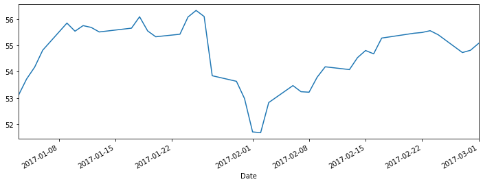

```python
# Dates are separated by a colon:
df['Close']['2017-01-01':'2017-03-01'].plot(figsize=(12,4)).autoscale(axis='x',tight=True);
```

### Choosing X Limits by Argument:

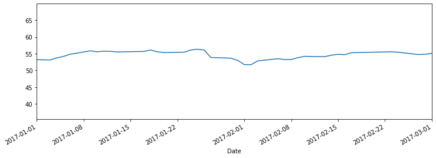

```python
# Dates are separated by a comma:
#Let's say we want to display the plot only from the 1st of january until the 1t of march
df['Close'].plot(figsize=(12,4),xlim=['2017-01-01','2017-03-01']);
```

Now let's focus on the y-axis limits to get a better sense of the shape of the data.  
First we'll find out what upper and lower limits to use.

```python
# FIND THE MINIMUM VALUE IN THE RANGE:
df.loc['2017-01-01':'2017-03-01']['Close'].min()
```

```
51.6899
```

## Title and axis labels

Let's add a title and axis labels to our subplot.

**REMEMBER:** `ax.autoscale(axis='both',tight=True)` is unnecessary if axis limits have been passed into `.plot()`.  
If we were to add it, autoscale would revert the axis limits to the full dataset.

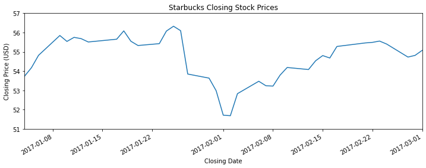

```python
title='Starbucks Closing Stock Prices'
ylabel='Closing Price (USD)'
xlabel='Closing Date'

ax = df['Close'].plot(xlim=['2017-01-04','2017-03-01'],ylim=[51,57],figsize=(12,4),title=title)
ax.set(xlabel=xlabel, ylabel=ylabel);
```

We can pass arguments into `.plot()` to change the linestyle and color. Refer to the Customizing Plots lecture from the previous section for more options.

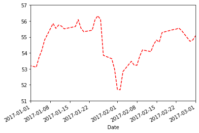

```python
df['Close'].plot(xlim=['2017-01-01','2017-03-01'],ylim=[51,57],ls='--',c='r');
```

## X Ticks

In this section we'll look at how to change the format and appearance of dates along the x-axis. To do this, we'll borrow a tool from `matplotlib` called `dates`.

### Set the spacing

The x-axis values can be divided into major and minor axes. For now, we'll work only with the major axis and learn how to set the spacing with `.set_major_locator()`. As you can see in the graph below, the X axis is not beautifully distributed

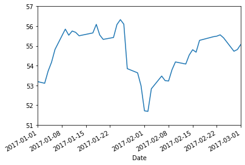

```python
# CREATE OUR AXIS OBJECT
ax = df['Close'].plot(xlim=['2017-01-01','2017-03-01'],ylim=[51,57])
```

With set_major_locator we can solve this problem

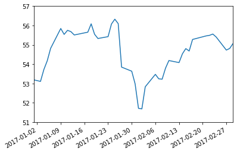

```python
# CREATE OUR AXIS OBJECT
ax = df['Close'].plot(xlim=['2017-01-01','2017-03-01'],ylim=[51,57])

# REMOVE PANDAS DEFAULT "Date" LABEL
ax.set(xlabel='')

# SET THE TICK LOCATOR AND FORMATTER FOR THE MAJOR AXIS
# byweekday = 0 means Monday

ax.xaxis.set_major_locator(dates.WeekdayLocator(byweekday=0))
```

Notice that dates are spaced one week apart. The dates themselves correspond with `byweekday=0`, or Mondays.  
For a full list of locator options available from `matplotlib.dates` visit https://matplotlib.org/api/dates_api.html#date-tickers

### Date Formatting

Formatting follows the Python datetime **[strftime](http://strftime.org/)** codes.  
The following examples are based on `datetime.datetime(2001, 2, 3, 16, 5, 6)`:

| CODE | MEANING | EXAMPLE |
| --- | --- | --- |
| %Y | Year with century as a decimal number. | 2001 |
| %y | Year without century as a zero-padded decimal number. | 01 |
| %m | Month as a zero-padded decimal number. | 02 |
| %B | Month as locale’s full name. | February |
| %b | Month as locale’s abbreviated name. | Feb |
| %d | Day of the month as a zero-padded decimal number. | 03 |
| %A | Weekday as locale’s full name. | Saturday |
| %a | Weekday as locale’s abbreviated name. | Sat |
| %H | Hour (24-hour clock) as a zero-padded decimal number. | 16 |
| %I | Hour (12-hour clock) as a zero-padded decimal number. | 04 |
| %p | Locale’s equivalent of either AM or PM. | PM |
| %M | Minute as a zero-padded decimal number. | 05 |
| %S | Second as a zero-padded decimal number. | 06 |

| CODE | MEANING | EXAMPLE |
| --- | --- | --- |
| %#m | Month as a decimal number. (Windows) | 2 |
| %-m | Month as a decimal number. (Mac/Linux) | 2 |
| %#x | Long date | Saturday, February 03, 2001 |
| %#c | Long date and time | Saturday, February 03, 2001 16:05:06 |

```python
# USE THIS SPACE TO EXPERIMENT WITH DIFFERENT FORMATS
from datetime import datetime
datetime(2001, 2, 3, 16, 5, 6).strftime("%A, %B %d, %Y  %I:%M:%S %p")
```

```
'Saturday, February 03, 2001  04:05:06 PM'
```

We use the set_major_formatter to format the display of the date in the plot

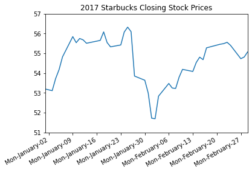

```python
ax = df['Close'].plot(xlim=['2017-01-01','2017-03-01'],ylim=[51,57],title='2017 Starbucks Closing Stock Prices')
ax.set(xlabel='')

ax.xaxis.set_major_locator(dates.WeekdayLocator(byweekday=0))
ax.xaxis.set_major_formatter(dates.DateFormatter("%a-%B-%d"))
```

## Major vs. Minor Axis Values

All of the tick marks we've used so far have belonged to the major axis. We can assign another level called the *minor axis*, perhaps to separate month names from days of the month.

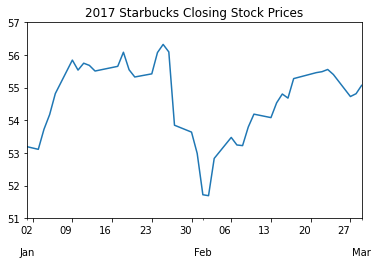

```python
ax = df['Close'].plot(xlim=['2017-01-01','2017-03-01'],ylim=[51,57],rot=0,title='2017 Starbucks Closing Stock Prices')
ax.set(xlabel='')

ax.xaxis.set_major_locator(dates.WeekdayLocator(byweekday=0))
ax.xaxis.set_major_formatter(dates.DateFormatter('%d'))

ax.xaxis.set_minor_locator(dates.MonthLocator())
ax.xaxis.set_minor_formatter(dates.DateFormatter('\n\n%b'))
```

## Adding Gridlines

We can add x and y axis gridlines that extend into the plot from each major tick mark.

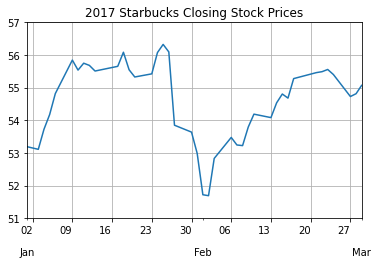

```python
ax = df['Close'].plot(xlim=['2017-01-01','2017-03-01'],ylim=[51,57],rot=0,title='2017 Starbucks Closing Stock Prices')
ax.set(xlabel='')

ax.xaxis.set_major_locator(dates.WeekdayLocator(byweekday=0))
ax.xaxis.set_major_formatter(dates.DateFormatter('%d'))

ax.xaxis.set_minor_locator(dates.MonthLocator())
ax.xaxis.set_minor_formatter(dates.DateFormatter('\n\n%b'))

ax.yaxis.grid(True)
ax.xaxis.grid(True)
```

# TIME SERIES

## Statsmodels

### For Further Reading:

**[Statsmodels Tutorial:](http://www.statsmodels.org/stable/tsa.html)** Time Series Analysis

Let's walk through a very simple example of using statsmodels!

### Perform standard imports and load the dataset

For these exercises we'll be using a statsmodels built-in macroeconomics dataset:

```
US Macroeconomic Data for 1959Q1 - 2009Q3
Number of Observations - 203
Number of Variables - 14
Variable name definitions:
    year      - 1959q1 - 2009q3
    quarter   - 1-4
    realgdp   - Real gross domestic product (Bil. of chained 2005 US$,
                seasonally adjusted annual rate)
    realcons  - Real personal consumption expenditures (Bil. of chained
                2005 US$, seasonally adjusted annual rate)
    realinv   - Real gross private domestic investment (Bil. of chained
                2005 US$, seasonally adjusted annual rate)
    realgovt  - Real federal consumption expenditures & gross investment
                (Bil. of chained 2005 US$, seasonally adjusted annual rate)
    realdpi   - Real private disposable income (Bil. of chained 2005
                US$, seasonally adjusted annual rate)
    cpi       - End of the quarter consumer price index for all urban
                consumers: all items (1982-84 = 100, seasonally adjusted).
    m1        - End of the quarter M1 nominal money stock (Seasonally
                adjusted)
    tbilrate  - Quarterly monthly average of the monthly 3-month
                treasury bill: secondary market rate
    unemp     - Seasonally adjusted unemployment rate (%)
    pop       - End of the quarter total population: all ages incl. armed
                forces over seas
    infl      - Inflation rate (ln(cpi_{t}/cpi_{t-1}) * 400)
    realint   - Real interest rate (tbilrate - infl)
```

**NOTE:** Although we've provided a .csv file in the Data folder, you can also build this DataFrame with the following code:

```
    import pandas as pd

    import statsmodels.api as sm

    df = sm.datasets.macrodata.load_pandas().data

    df.index = pd.Index(sm.tsa.datetools.dates_from_range('1959Q1', '2009Q3'))

    print(sm.datasets.macrodata.NOTE)
```

```python
from statsmodels.tsa.filters.hp_filter import hpfilter
df = pd.read_csv('./original/TSA_COURSE_NOTEBOOKS/Data/macrodata.csv',index_col=0,parse_dates=True)
df.head()
```

|  | year | quarter | realgdp | realcons | realinv | realgovt | realdpi | cpi | m1 | tbilrate | unemp | pop | infl | realint |
| --- | --- | --- | --- | --- | --- | --- | --- | --- | --- | --- | --- | --- | --- | --- |
| 1959-03-31 | 1959 | 1 | 2710.349 | 1707.4 | 286.898 | 470.045 | 1886.9 | 28.98 | 139.7 | 2.82 | 5.8 | 177.146 | 0.00 | 0.00 |
| 1959-06-30 | 1959 | 2 | 2778.801 | 1733.7 | 310.859 | 481.301 | 1919.7 | 29.15 | 141.7 | 3.08 | 5.1 | 177.830 | 2.34 | 0.74 |
| 1959-09-30 | 1959 | 3 | 2775.488 | 1751.8 | 289.226 | 491.260 | 1916.4 | 29.35 | 140.5 | 3.82 | 5.3 | 178.657 | 2.74 | 1.09 |
| 1959-12-31 | 1959 | 4 | 2785.204 | 1753.7 | 299.356 | 484.052 | 1931.3 | 29.37 | 140.0 | 4.33 | 5.6 | 179.386 | 0.27 | 4.06 |
| 1960-03-31 | 1960 | 1 | 2847.699 | 1770.5 | 331.722 | 462.199 | 1955.5 | 29.54 | 139.6 | 3.50 | 5.2 | 180.007 | 2.31 | 1.19 |

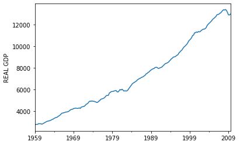

```python
ax = df['realgdp'].plot()
ax.autoscale(axis='x',tight=True)
ax.set(ylabel='REAL GDP');
```

## Using Statsmodels to get the trend

### Related Function:

`statsmodels.tsa.filters.hp_filter.hpfilter(X, lamb=1600) Hodrick-Prescott filter`

The [Hodrick-Prescott filter](https://en.wikipedia.org/wiki/Hodrick%E2%80%93Prescott_filter) separates a time-series $y_t$ into a trend component $\tau_t$ and a cyclical component $c_t$

$y_t = \tau_t + c_t$

The components are determined by minimizing the following quadratic loss function, where $\lambda$ is a smoothing parameter:

$\min_{\\{ \tau_{t}\\} }\sum_{t=1}^{T}c_{t}^{2}+\lambda\sum_{t=1}^{T}\left[\left(\tau_{t}-\tau_{t-1}\right)-\left(\tau_{t-1}-\tau_{t-2}\right)\right]^{2}$

The $\lambda$ value above handles variations in the growth rate of the trend component.  
When analyzing quarterly data, the default lambda value of 1600 is recommended. Use 6.25 for annual data, and 129,600 for monthly data.

The following function extracts the cycle and trend component and returns it

## Hodrick-Prescott filter

```python
# Tuple unpacking
gdp_cycle, gdp_trend = hpfilter(df['realgdp'], lamb=1600)
#Both are a pandas.core.series.Series
```

Let's plot the results

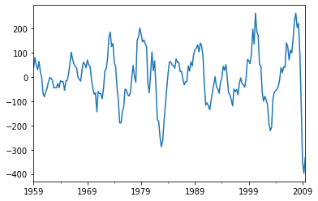

```python
gdp_cycle.plot();
```

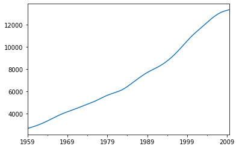

```python
gdp_trend.plot();
```

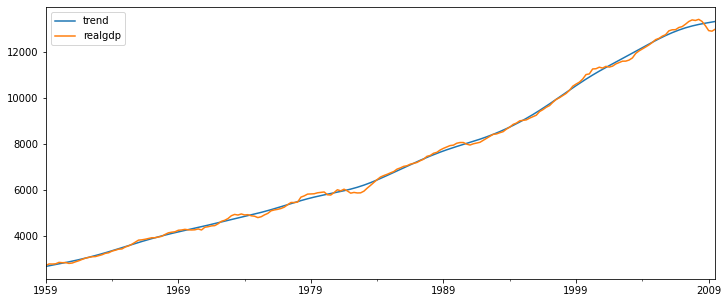

```python
df['trend'] = gdp_trend
df[['trend','realgdp']].plot(figsize=(12,5)).autoscale(axis='x',tight=True);
```

## Error/Trend/Seasonality Models

As we begin working with *endogenous* data ("endog" for short) and start to develop forecasting models, it helps to identify and isolate factors working within the system that influence behavior. Here the name "endogenous" considers internal factors, while "exogenous" would relate to external forces. These fall under the category of *state space models*, and include *decomposition* (described below), and *exponential smoothing* (described in an upcoming section).

The [decomposition](https://en.wikipedia.org/wiki/Decomposition_of_time_series) of a time series attempts to isolate individual components such as *error*, *trend*, and *seasonality* (ETS). We've already seen a simplistic example of this in the **Introduction to Statsmodels** section with the Hodrick-Prescott filter. There we separated data into a trendline and a cyclical feature that mapped observed data back to the trend.

### Related Function:

```
statsmodels.tsa.seasonal.seasonal_decompose(x, model)
Seasonal decomposition using moving averages
```

### For Further Reading:

**[Forecasting: Principles and Practice](https://otexts.com/fpp2/ets.html)** Innovations state space models for exponential smoothing  
**[Wikipedia](https://en.wikipedia.org/wiki/Decomposition_of_time_series)** Decomposition of time series

## Seasonal Decomposition

Statsmodels provides a *seasonal decomposition* tool we can use to separate out the different components. This lets us see quickly and visually what each component contributes to the overall behavior.

We apply an **additive** model when it seems that the trend is more linear and the seasonality and trend components seem to be constant over time (e.g. every year we add 10,000 passengers).  
A **multiplicative** model is more appropriate when we are increasing (or decreasing) at a non-linear rate (e.g. each year we double the amount of passengers).

For these examples we'll use the International Airline Passengers dataset, which gives monthly totals in thousands from January 1949 to December 1960.

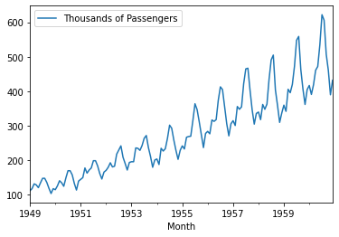

```python
from statsmodels.tsa.seasonal import seasonal_decompose

airline = pd.read_csv('./original/TSA_COURSE_NOTEBOOKS/Data/airline_passengers.csv',index_col='Month',parse_dates=True)

airline.dropna(inplace=True)

airline.plot();
```

Using the seasonal_decompose from statsmodels we will decompose the time series into its components:

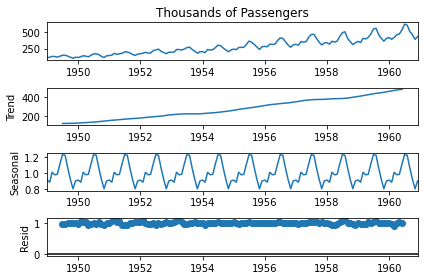

```python
result = seasonal_decompose(airline['Thousands of Passengers'], model='multiplicative')  # model='mul' also works
result.plot();
```

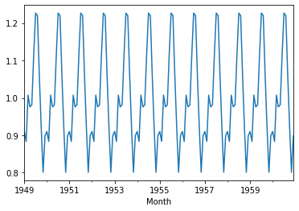

```python
#press on tab to check the different components
result.seasonal.plot();
```

# SMA

## Simple Moving Average

We've already shown how to create a [simple moving average](https://en.wikipedia.org/wiki/Moving_average#Simple_moving_average) by applying a `mean` function to a rolling window.

For a quick review

```python
airline['6-month-SMA'] = airline['Thousands of Passengers'].rolling(window=6).mean()
airline['12-month-SMA'] = airline['Thousands of Passengers'].rolling(window=12).mean()
```

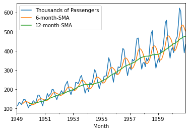

```python
airline.plot();
```

# EWMA-Exponentially-Weighted-Moving-Average

We just showed how to calculate the SMA based on some window. However, basic SMA has some weaknesses:

- Smaller windows will lead to more noise, rather than signal
- It will always lag by the size of the window
- It will never reach to full peak or valley of the data due to the averaging.
- Does not really inform you about possible future behavior, all it really does is describe trends in your data.
- Extreme historical values can skew your SMA significantly

To help fix some of these issues, we can use an [EWMA (Exponentially weighted moving average)](https://en.wikipedia.org/wiki/Exponential_smoothing).

EWMA will allow us to reduce the lag effect from SMA and it will put more weight on values that occured more recently (by applying more weight to the more recent values, thus the name). The amount of weight applied to the most recent values will depend on the actual parameters used in the EWMA and the number of periods given a window size. [Full details on Mathematics behind this can be found here](http://pandas.pydata.org/pandas-docs/stable/user_guide/computation.html#exponentially-weighted-windows). Here is the shorter version of the explanation behind EWMA.

The formula for EWMA is:

### $y_t = \frac{\sum\limits_{i=0}^t w_i x_{t-i}}{\sum\limits_{i=0}^t w_i}$

Where $x_t$ is the input value, $w_i$ is the applied weight (Note how it can change from $i=0$ to $t$), and $y_t$ is the output.

Now the question is, how do we define the weight term $w_i$?

This depends on the `adjust` parameter you provide to the `.ewm()` method.

which is equivalent to using weights:

\begin{split}w_i = \begin{cases} \alpha (1 - \alpha)^i & \text{if } i < t \\ (1 - \alpha)^i & \text{if } i = t. \end{cases}\end{split}

The use of adjust=True or adjust=False, has to do whether a series is finite or infinite. In fact if you take an infinite series and pass it in the adjust=True formula, you will end up having the adjust=False formula.

For the smoothing factor $\alpha$ one must have $0<\alpha≤1$, and while it is possible to pass *alpha* directly, it’s often easier to think about either the *span*, *center of mass* (com) or *half-life* of an EW moment:

\begin{split}\alpha = \begin{cases} \frac{2}{s + 1}, & \text{for span}\ s \geq 1\\ \frac{1}{1 + c}, & \text{for center of mass}\ c \geq 0\\ 1 - \exp^{\frac{\log 0.5}{h}}, & \text{for half-life}\ h > 0 \end{cases}\end{split}

*Those are the ways alpha can be calculated, but you can also just input it manually*

- **Span** corresponds to what is commonly called an “N-day EW moving average”. It's the window.
- **Center of mass** has a more physical interpretation and can be thought of in terms of span: $c=(s−1)/2$
- **Half-life** is the period of time for the exponential weight to reduce to one half.
- **Alpha** specifies the smoothing factor directly.

We have to pass precisely one of the above into the `.ewm()` function. For our data we'll use `span=12`.

Disadvantages of EWMA:

```
- Does not take into account trend and seasonality.
```

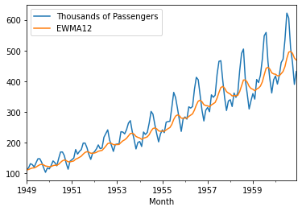

```python
# With span = 12, we are using al alpha = 2/(12+1). Look at the above formula.
# Therefore when we pass the parameter span in the formula, we are setting alpha
airline['EWMA12'] = airline['Thousands of Passengers'].ewm(span=12,adjust=False).mean()
airline[['Thousands of Passengers','EWMA12']].plot();
```

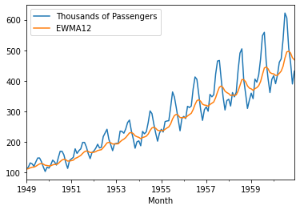

```python
airline['EWMA12'] = airline['Thousands of Passengers'].ewm(span=12,adjust=False).mean()
airline[['Thousands of Passengers','EWMA12']].plot();
```

## SMA vs EWMA

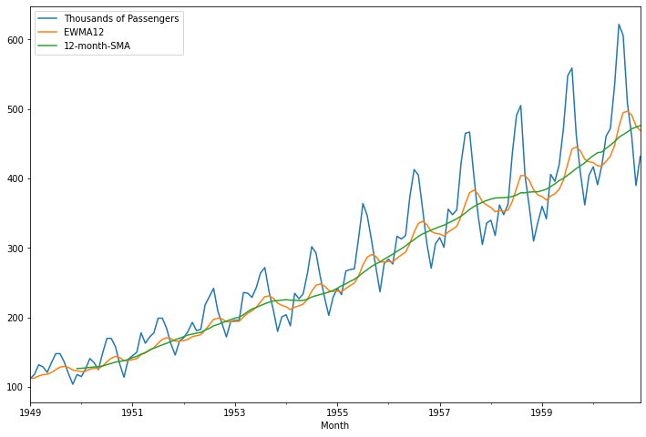

```python
airline[['Thousands of Passengers','EWMA12','12-month-SMA']].plot(figsize=(12,8)).autoscale(axis='x',tight=True);
```

# Holt-Winters Methods

In the previous section on **Exponentially Weighted Moving Averages** (EWMA) we applied *Simple Exponential Smoothing* using just one smoothing factor $\alpha$ (alpha). This failed to account for other contributing factors like trend and seasonality.

In this section we'll look at *Double* and *Triple Exponential Smoothing* with the [Holt-Winters Methods](https://otexts.com/fpp2/holt-winters.html).

In **Double Exponential Smoothing** (double is because we have 2 parameters) (aka Holt's Method) we introduce a new smoothing factor $\beta$ (beta) that addresses **trend** :

\begin{split}l_t &= (1 - \alpha) l_{t-1} + \alpha x_t, & \text{ level}\\ b_t &= (1-\beta)b_{t-1} + \beta(l_t-l_{t-1}) & \text{ trend}\\ y_t &= l_t + b_t & \text{ fitted model}\\ \hat y_{t+h} &= l_t + hb_t & \text{ forecasting model (} h = \text{# periods into the future)}\end{split}

Because we haven't yet considered seasonal fluctuations, the forecasting model is simply a straight sloped line extending from the most recent data point. We'll see an example of this in upcoming lectures.

With **Triple Exponential Smoothing** (aka the Holt-Winters Method) we introduce a smoothing factor $\gamma$ (gamma) that addresses seasonality:

\begin{split}l_t &= (1 - \alpha) l_{t-1} + \alpha x_t, & \text{ level}\\ b_t &= (1-\beta)b_{t-1} + \beta(l_t-l_{t-1}) & \text{ trend}\\ c_t &= (1-\gamma)c_{t-L} + \gamma(x_t-l_{t-1}-b_{t-1}) & \text{ seasonal}\\ y_t &= (l_t + b_t) c_t & \text{ fitted model}\\ \hat y_{t+m} &= (l_t + mb_t)c_{t-L+1+(m-1)modL} & \text{ forecasting model (} m = \text{# periods into the future)}\end{split}

Here $L$ represents the number of divisions per cycle. In our case looking at monthly data that displays a repeating pattern each year, we would use $L=12$.

In general, higher values for $\alpha$, $\beta$ and $\gamma$ (values closer to 1), place more emphasis on recent data.

### Related Functions:

```
statsmodels.tsa.holtwinters.SimpleExpSmoothing(endog)
Simple Exponential Smoothing

statsmodels.tsa.holtwinters.ExponentialSmoothing(endog)
    Holt-Winters Exponential Smoothing
```

### For Further Reading:

`NIST/SEMATECH e-Handbook of Statistical Methods What is Exponential Smoothing?`

# Simple Exponential Smoothing - Simple Moving Average

We worked on this above. Just as a reminder. A variation of the statmodels Holt-Winters function provides Simple Exponential Smoothing. We'll show that it performs the same calculation of the weighted moving average as the pandas `.ewm()` method:  
$\begin{split}y_0 &= x_0 \\ y_t &= (1 - \alpha) y_{t-1} + \alpha x_t,\end{split}$

```python
#We will keep using the arilines dataframe
df = pd.read_csv('./original/TSA_COURSE_NOTEBOOKS/Data/airline_passengers.csv',index_col='Month',parse_dates=True)

df.dropna(inplace=True)
```

Note that our DatetimeIndex does not have a frequency. In order to build a Holt-Winters smoothing model, statsmodels needs to know the frequency of the data (whether it's daily, monthly etc.). Since observations occur at the start of each month, we'll use MS.  
A full list of time series offset aliases can be found [here](http://pandas.pydata.org/pandas-docs/stable/user_guide/timeseries.html#offset-aliases).

```python
df.index
```

```
DatetimeIndex(['1949-01-01', '1949-02-01', '1949-03-01', '1949-04-01',
               '1949-05-01', '1949-06-01', '1949-07-01', '1949-08-01',
               '1949-09-01', '1949-10-01',
               ...
               '1960-03-01', '1960-04-01', '1960-05-01', '1960-06-01',
               '1960-07-01', '1960-08-01', '1960-09-01', '1960-10-01',
               '1960-11-01', '1960-12-01'],
              dtype='datetime64[ns]', name='Month', length=144, freq=None)
```

```python
df.index.freq = 'MS'
df.index
```

```
DatetimeIndex(['1949-01-01', '1949-02-01', '1949-03-01', '1949-04-01',
               '1949-05-01', '1949-06-01', '1949-07-01', '1949-08-01',
               '1949-09-01', '1949-10-01',
               ...
               '1960-03-01', '1960-04-01', '1960-05-01', '1960-06-01',
               '1960-07-01', '1960-08-01', '1960-09-01', '1960-10-01',
               '1960-11-01', '1960-12-01'],
              dtype='datetime64[ns]', name='Month', length=144, freq='MS')
```

```python
from statsmodels.tsa.holtwinters import SimpleExpSmoothing
span = 12
alpha = 2/(span+1)
#as we did in the previous cells
df['EWMA12'] = df['Thousands of Passengers'].ewm(alpha=alpha,adjust=False).mean()
```

Now we are going to implement the SIMPLE EXP SMOOTHING model, but first let's understand what is going on with the code:

```python
model = SimpleExpSmoothing(df['Thousands of Passengers'])
```

```python
# With Tab you can check the various attributes of the object "model", like "fit"
# As paremeters in the fit method we have the smoothing_level which is alpha
fitted_model =  model.fit(smoothing_level=alpha,optimized=False)

# This returns a HoltWintersResultsWrapper

fitted_model.fittedvalues
```

```
Month
1949-01-01    112.000000
1949-02-01    112.000000
1949-03-01    112.923077
1949-04-01    115.857988
1949-05-01    117.879836
                 ...
1960-08-01    474.698368
1960-09-01    494.898619
1960-10-01    496.914216
1960-11-01    491.388952
1960-12-01    475.790652
Freq: MS, Length: 144, dtype: float64
```

**NOTE:** For some reason, when `optimized=False` is passed into `.fit()`, the statsmodels `SimpleExpSmoothing` function shifts fitted values down one row. We fix this by adding `.shift(-1)` after `.fittedvalues`

```python
# We will simply solve the problem with the shift function

fitted_model.fittedvalues.shift(-1)
```

```
Month
1949-01-01    112.000000
1949-02-01    112.923077
1949-03-01    115.857988
1949-04-01    117.879836
1949-05-01    118.359861
                 ...
1960-08-01    494.898619
1960-09-01    496.914216
1960-10-01    491.388952
1960-11-01    475.790652
1960-12-01           NaN
Freq: MS, Length: 144, dtype: float64
```

```python
# we add the predictions to our dataframe

df['SES12'] = fitted_model.fittedvalues.shift(-1)
```

```python
df.head()
```

| Month | Thousands of Passengers | EWMA12 | SES12 |
| --- | --- | --- | --- |
| 1949-01-01 | 112 | 112.000000 | 112.000000 |
| 1949-02-01 | 118 | 112.923077 | 112.923077 |
| 1949-03-01 | 132 | 115.857988 | 115.857988 |
| 1949-04-01 | 129 | 117.879836 | 117.879836 |
| 1949-05-01 | 121 | 118.359861 | 118.359861 |

Note that we could have simply put all the code in the cells into one line of code:

```python
#df['SES12']=SimpleExpSmoothing(df['Thousands of Passengers']).fit(smoothing_level=alpha,optimized=False).fittedvalues.shift(-1)
```

```python
df
```

| Month | Thousands of Passengers | EWMA12 | SES12 |
| --- | --- | --- | --- |
| 1949-01-01 | 112 | 112.000000 | 112.000000 |
| 1949-02-01 | 118 | 112.923077 | 112.923077 |
| 1949-03-01 | 132 | 115.857988 | 115.857988 |
| 1949-04-01 | 129 | 117.879836 | 117.879836 |
| 1949-05-01 | 121 | 118.359861 | 118.359861 |
| ... | ... | ... | ... |
| 1960-08-01 | 606 | 494.898619 | 494.898619 |
| 1960-09-01 | 508 | 496.914216 | 496.914216 |
| 1960-10-01 | 461 | 491.388952 | 491.388952 |
| 1960-11-01 | 390 | 475.790652 | 475.790652 |
| 1960-12-01 | 432 | 469.053629 | NaN |

144 rows × 3 columns

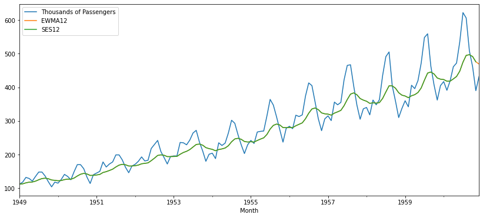

```python
# EWMA12 and SES12 are the same in this particular case
df.plot(figsize=(14,6))
```

Now that we have the Simple Exponential Smoothing, let's try the Double Exponential Smoothing, before we plot the results.

## Double Exponential Smoothing - Holt's Method

Where Simple Exponential Smoothing employs just one smoothing factor $\alpha$ (alpha), Double Exponential Smoothing adds a second smoothing factor $\beta$ (beta) that addresses trends in the data. Like the alpha factor, values for the beta factor fall between zero and one ($0<\beta≤1$). The benefit here is that the model can anticipate future increases or decreases where the level model would only work from recent calculations.

We can also address different types of change (growth/decay) in the trend. If a time series displays a straight-line sloped trend, you would use an **additive** adjustment. If the time series displays an exponential (curved) trend, you would use a **multiplicative** adjustment.

As we move toward forecasting, it's worth noting that both additive and multiplicative adjustments may become exaggerated over time, and require *damping* that reduces the size of the trend over future periods until it reaches a flat line.

```python
from statsmodels.tsa.holtwinters import ExponentialSmoothing

#It's hard to say wethet the passengers data has a multiplicative or additive trend, we will assume it is additive


df['DESadd12'] = ExponentialSmoothing(df['Thousands of Passengers'], trend='add').fit().fittedvalues.shift(-1)
df.head()
```

| Month | Thousands of Passengers | EWMA12 | SES12 | DESadd12 |
| --- | --- | --- | --- | --- |
| 1949-01-01 | 112 | 112.000000 | 112.000000 | 114.237773 |
| 1949-02-01 | 118 | 112.923077 | 112.923077 | 120.237773 |
| 1949-03-01 | 132 | 115.857988 | 115.857988 | 134.237773 |
| 1949-04-01 | 129 | 117.879836 | 117.879836 | 131.237773 |
| 1949-05-01 | 121 | 118.359861 | 118.359861 | 123.237773 |

The DESadd12 is almost the same as the number of passangers (the blue line is just behind the red)

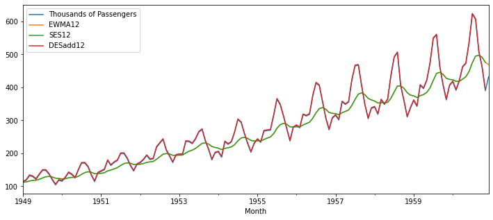

```python
df.plot(figsize=(12,5))
```

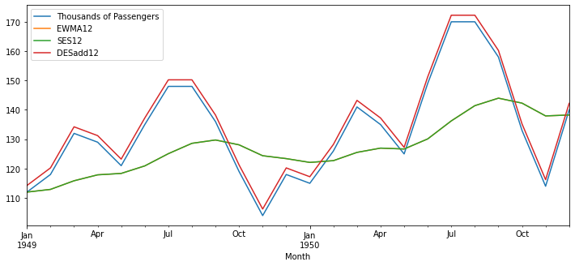

```python
# Let's do some Zoom
df.iloc[:24].plot(figsize=(12,5))
```

Double exponential is clearly better than Simple

What about Tripple ?

## Triple Exponential Smoothing - Holt-Winters Method

Triple Exponential Smoothing, the method most closely associated with Holt-Winters, adds support for both trends and seasonality in the data.

```python
df['TESadd12'] = ExponentialSmoothing(df['Thousands of Passengers'],trend='add',seasonal='add',seasonal_periods=12).fit().fittedvalues
df.head()
```

| Month | Thousands of Passengers | EWMA12 | SES12 | DESadd12 | TESadd12 |
| --- | --- | --- | --- | --- | --- |
| 1949-01-01 | 112 | 112.000000 | 112.000000 | 114.237773 | 113.081288 |
| 1949-02-01 | 118 | 112.923077 | 112.923077 | 120.237773 | 120.550747 |
| 1949-03-01 | 132 | 115.857988 | 115.857988 | 134.237773 | 135.527329 |
| 1949-04-01 | 129 | 117.879836 | 117.879836 | 131.237773 | 133.155064 |
| 1949-05-01 | 121 | 118.359861 | 118.359861 | 123.237773 | 125.656114 |

```python
df['TESmul12'] = ExponentialSmoothing(df['Thousands of Passengers'],trend='mul',seasonal='mul',seasonal_periods=12).fit().fittedvalues
df.head()
```

| Month | Thousands of Passengers | EWMA12 | SES12 | DESadd12 | TESadd12 | TESmul12 |
| --- | --- | --- | --- | --- | --- | --- |
| 1949-01-01 | 112 | 112.000000 | 112.000000 | 114.237773 | 113.081288 | 111.614584 |
| 1949-02-01 | 118 | 112.923077 | 112.923077 | 120.237773 | 120.550747 | 118.856901 |
| 1949-03-01 | 132 | 115.857988 | 115.857988 | 134.237773 | 135.527329 | 133.344660 |
| 1949-04-01 | 129 | 117.879836 | 117.879836 | 131.237773 | 133.155064 | 127.916273 |
| 1949-05-01 | 121 | 118.359861 | 118.359861 | 123.237773 | 125.656114 | 120.993591 |

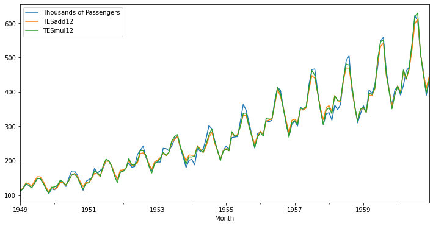

```python
df[['Thousands of Passengers','TESadd12','TESmul12']].plot(figsize=(12,6)).autoscale(axis='x',tight=True);
```

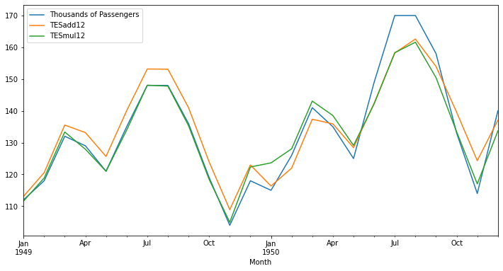

```python
# Let's chekc for the first 2 years (24 months)
df[['Thousands of Passengers','TESadd12','TESmul12']].iloc[:24].plot(figsize=(12,6)).autoscale(axis='x',tight=True);
```

# Forecasting

In the previous section we fit various smoothing models to existing data. So the purpose was not to forecast, but predict. The purpose now is to predict what happens next.  
What's our best guess for next month's value? For the next six months?

In this section we'll look to extend our models into the future. First we'll divide known data into training and testing sets, and evaluate the performance of a trained model on known test data.

- Goals
  - Compare a Holt-Winters forecasted model to known data
  - Understand *stationarity*, *differencing* and *lagging*
  - Introduce ARIMA and describe next steps

The **Forecasting Procedure** looks like:

- Modle selection
- Splitting data into train and test sets
- Fit model on training set
- Evaluate model on test set
- Re-fit model on entire data set
- Forecast for future data

## Forecasting with the Holt-Winters Method

```python
df = pd.read_csv('./original/TSA_COURSE_NOTEBOOKS/Data/airline_passengers.csv',index_col='Month',parse_dates=True)
df.index.freq = 'MS'
df.head()
```

| Month | Thousands of Passengers |
| --- | --- |
| 1949-01-01 | 112 |
| 1949-02-01 | 118 |
| 1949-03-01 | 132 |
| 1949-04-01 | 129 |
| 1949-05-01 | 121 |

### Train Test Split

```python
train_data = df.iloc[:109] # Goes up to but not including 109
test_data = df.iloc[108:]
```

### Fitting the Model

```python
from statsmodels.tsa.holtwinters import ExponentialSmoothing

fitted_model = ExponentialSmoothing(train_data['Thousands of Passengers'],trend='mul',seasonal='mul',seasonal_periods=12).fit()
```

### Evaluating model against test

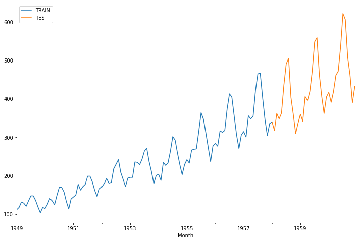

```python
train_data['Thousands of Passengers'].plot(legend=True,label='TRAIN')
test_data['Thousands of Passengers'].plot(legend=True,label='TEST',figsize=(12,8));
```

```python
test_predictions = fitted_model.forecast(36).rename('HW Forecast')
```

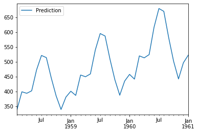

```python
test_predictions.plot(legend=True, label="Prediction")
```

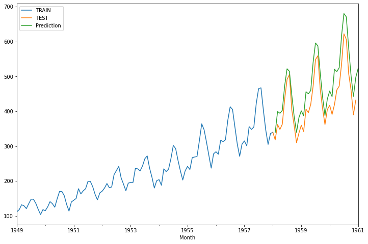

```python
train_data['Thousands of Passengers'].plot(legend=True,label='TRAIN')
test_data['Thousands of Passengers'].plot(legend=True,label='TEST',figsize=(12,8));
test_predictions.plot(legend=True, label="Prediction")
```

Recall and accuracy are not appropiate evaluation metrics for forecasting techniques. We need metrics designed for continuous values

## Evaluation Metrics

Let's analyse how can we use the most baic regression evaluation metrics

```
* Mean Absolute Error
* Mean Squared Error
* Root Mean Square Error
```

```python
from sklearn.metrics import mean_squared_error,mean_absolute_error
```

### Mean Absolute Error

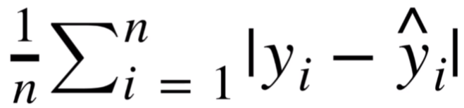

being y the true value and y hat the predicted value

Disadvantages: It does not take into account if a few predicted points are actually very far away from real points. Exmaple: imagine spending for a mktg campaign is very high in december (Xmas) and the rest of the months is similar, then the MAE might not show us the effect of that month, since it is a mean.

Therefore we have the MSE as a solution

```python
mean_absolute_error(test_data, test_predictions)
```

```
63.03016344745991
```

To analyse the MAE, you can check the summary key figures of the test data

```python
test_data.describe()
```

|  | Thousands of Passengers |
| --- | --- |
| count | 36.000000 |
| mean | 428.500000 |
| std | 79.329152 |
| min | 310.000000 |
| 25% | 362.000000 |
| 50% | 412.000000 |
| 75% | 472.000000 |
| max | 622.000000 |

### Mean Squared Error

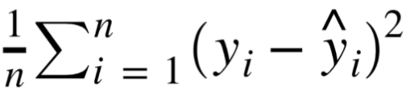

Since it is squared, those predicted points that are very far away from the real ones will have more importance in the calculation. You punish the model by having large errors.

Of course this means we cannot interpret directly the result (since it is squared). So we have the RMSE for this

### Root Mean Square Error

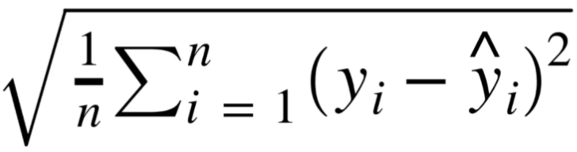

Squaring it we get the units back in its original form (like std with the variance). The intepretation dependends then on the data. A RMSE of 20€ of the price of a house is a very good, but for candy it's not.

```python
np.sqrt(mean_squared_error(test_data,test_predictions))
```

```
74.92727460739599
```

Our mean squarred error is less than our standard deviation. Therefore, the method is not doing a bad job

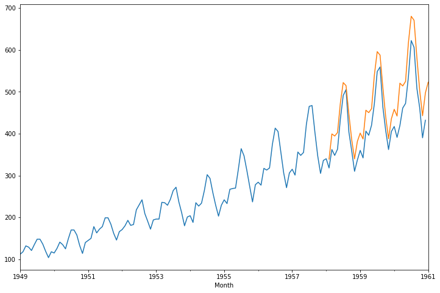

```python
#We creat the fitted model object
fitted_model = ExponentialSmoothing(train_data['Thousands of Passengers'],trend='mul',seasonal='mul',seasonal_periods=12).fit()

forecast_predictions= fitted_model.forecast(36)

df['Thousands of Passengers'].plot(figsize=(12,8))
forecast_predictions.plot();
```

## Stationarity

Time series data is said to be *stationary* if it does *not* exhibit trends or seasonality. That is, fluctuations in the data are entirely due to outside forces and noise. The file `samples.csv` contains made-up datasets that illustrate stationary and non-stationary data.

```python
df2 = pd.read_csv('./original/TSA_COURSE_NOTEBOOKS/Data/samples.csv',index_col=0,parse_dates=True)
df2.head()
```

|  | a | b | c |
| --- | --- | --- | --- |
| 1950-01-01 | 36 | 27 | 0 |
| 1950-02-01 | 58 | 22 | 3 |
| 1950-03-01 | 61 | 17 | 5 |
| 1950-04-01 | 37 | 15 | 8 |
| 1950-05-01 | 66 | 13 | 8 |

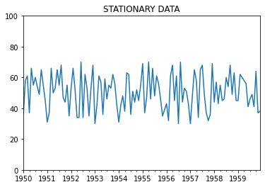

```python
df2['a'].plot(ylim=[0,100],title="STATIONARY DATA").autoscale(axis='x',tight=True);
```

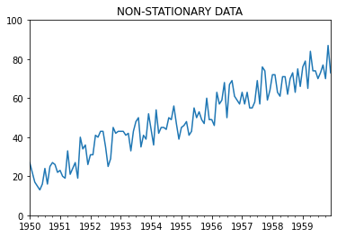

```python
df2['b'].plot(ylim=[0,100],title="NON-STATIONARY DATA").autoscale(axis='x',tight=True);
```

## Differencing

Non-stationary data can be made to look stationary through *differencing*. A simple differencing method calculates the difference between consecutive points.

### Related Functions:

`statespace.tools.diff(series[, k_diff, …]) Difference a series simply and/or seasonally along the zero-th axis.`

You can calculate manually the first order difference by substracting:

```python
df2["b"]-df2["b"].shift(1)
```

```
1950-01-01     NaN
1950-02-01    -5.0
1950-03-01    -5.0
1950-04-01    -2.0
1950-05-01    -2.0
              ...
1959-08-01     3.0
1959-09-01     4.0
1959-10-01    -7.0
1959-11-01    17.0
1959-12-01   -14.0
Name: b, Length: 120, dtype: float64
```

But statsmodels has a function that does it for you

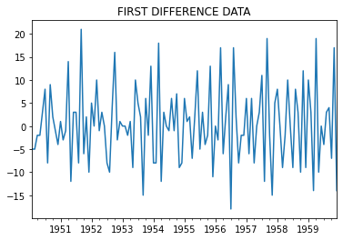

```python
from statsmodels.tsa.statespace.tools import diff
df2['d1'] = diff(df2['b'],k_diff=1)

df2['d1'].plot(title="FIRST DIFFERENCE DATA").autoscale(axis='x',tight=True);
```

# Introduction to ARIMA Models

We'll investigate a variety of different forecasting models in upcoming sections, but they all stem from ARIMA.

**ARIMA**, or *Autoregressive Integrated Moving Average* is actually a combination of 3 models:

- **AR(p)** Autoregression - a regression model that utilizes the dependent relationship between a current observation and observations over a previous period
- **I(d)** Integration - uses differencing of observations (subtracting an observation from an observation at the previous time step) in order to make the time series stationary
- **MA(q)** Moving Average - a model that uses the dependency between an observation and a residual error from a moving average model applied to lagged observations.

**Moving Averages** we've already seen with EWMA and the Holt-Winters Method.  
**Integration** will apply differencing to make a time series stationary, which ARIMA requires.  
**Autoregression** is explained in detail in the next section. Here we're going to correlate a current time series with a lagged version of the same series.  
Once we understand the components, we'll investigate how to best choose the $p$, $d$ and $q$ values required by the model.

For times series the covariance (autocovariance) will be: ${\displaystyle \gamma_k = \frac 1 n \sum\limits_{t=1}^{n-k} (y_t - \bar{y})(y_{t+k}-\bar{y})}$

### Autocovariance Example:

Say we have a time series with five observations: {13, 5, 11, 12, 9}.  
We can quickly see that $n = 5$, the mean $\bar{y} = 10$, and we'll see that the variance $\sigma^2 = 8$.  
The following calculations give us our covariance values:  
$\gamma_0 = \frac {(13-10)(13-10)+(5-10)(5-10)+(11-10)(11-10)+(12-10)(12-10)+(9-10)(9-10)} 5 = \frac {40} 5 = 8.0 \\ \gamma_1 = \frac {(13-10)(5-10)+(5-10)(11-10)+(11-10)(12-10)+(12-10)(9-10)} 5 = \frac {-20} 5 = -4.0 \\ \gamma_2 = \frac {(13-10)(11-10)+(5-10)(12-10)+(11-10)(9-10)} 5 = \frac {-8} 5 = -1.6 \\ \gamma_3 = \frac {(13-10)(12-10)+(5-10)(9-10)} 5 = \frac {11} 5 = 2.2 \\ \gamma_4 = \frac {(13-10)(9-10)} 5 = \frac {-3} 5 = -0.6$  
Note that $\gamma_0$ is just the population variance $\sigma^2$

Let's see if statsmodels gives us the same results! For this we'll create a **fake** dataset:

```python
import pandas as pd
import numpy as np
%matplotlib inline
import statsmodels.api as sm
# Import the models we'll be using in this section
from statsmodels.tsa.stattools import acovf,acf,pacf,pacf_yw,pacf_ols
from pandas.plotting import lag_plot


import warnings
warnings.filterwarnings("ignore")
df = pd.DataFrame({'a':[13, 5, 11, 12, 9]})
arr = acovf(df['a'])
arr
```

```
array([ 8. , -4. , -1.6,  2.2, -0.6])
```

### Unbiased Autocovariance

Note that the number of terms in the calculations above are decreasing.  
Statsmodels can return an "unbiased" autocovariance where instead of dividing by $n$ we divide by $n-k$.

$\gamma_0 = \frac {(13-10)(13-10)+(5-10)(5-10)+(11-10)(11-10)+(12-10)(12-10)+(9-10)(9-10)} {5-0} = \frac {40} 5 = 8.0 \\ \gamma_1 = \frac {(13-10)(5-10)+(5-10)(11-10)+(11-10)(12-10)+(12-10)(9-10)} {5-1} = \frac {-20} 4 = -5.0 \\ \gamma_2 = \frac {(13-10)(11-10)+(5-10)(12-10)+(11-10)(9-10)} {5-2} = \frac {-8} 3 = -2.67 \\ \gamma_3 = \frac {(13-10)(12-10)+(5-10)(9-10)} {5-3} = \frac {11} 2 = 5.5 \\ \gamma_4 = \frac {(13-10)(9-10)} {5-4} = \frac {-3} 1 = -3.0$

```python
arr2 = acovf(df['a'],unbiased=True)
arr2
```

```
array([ 8.        , -5.        , -2.66666667,  5.5       , -3.        ])
```

## Autocorrelation for 1D

The correlation $\rho$ (rho) between two variables $y_1,y_2$ is given as:

### $\rho = \frac {\operatorname E[(y_1−\mu_1)(y_2−\mu_2)]} {\sigma_{1}\sigma_{2}} = \frac {\operatorname {Cov} (y_1,y_2)} {\sigma_{1}\sigma_{2}}$,

where $E$ is the expectation operator, $\mu_{1},\sigma_{1}$ and $\mu_{2},\sigma_{2}$ are the means and standard deviations of $y_1$ and $y_2$.

When working with a single variable (i.e. *autocorrelation*) we would consider $y_1$ to be the original series and $y_2$ a lagged version of it. Note that with autocorrelation we work with $\bar y$, that is, the full population mean, and *not* the means of the reduced set of lagged factors (see note below).

Thus, the formula for $\rho_k$ for a time series at lag $k$ is:

${\displaystyle \rho_k = \frac {\sum\limits_{t=1}^{n-k} (y_t - \bar{y})(y_{t+k}-\bar{y})} {\sum\limits_{t=1}^{n} (y_t - \bar{y})^2}}$

This can be written in terms of the covariance constant $\gamma_k$ as:

${\displaystyle \rho_k = \frac {\gamma_k n} {\gamma_0 n} = \frac {\gamma_k} {\sigma^2}}$

For example,  
$\rho_4 = \frac {\gamma_4} {\sigma^2} = \frac{-0.6} {8} = -0.075$

Note that ACF values are bound by -1 and 1. That is, ${\displaystyle -1 \leq \rho_k \leq 1}$

```python
arr3 = acf(df['a'])
arr3
```

```
array([ 1.   , -0.5  , -0.2  ,  0.275, -0.075])
```

## Partial Autocorrelation

Partial autocorrelations measure the linear dependence of one variable after removing the effect of other variable(s) that affect both variables. That is, the partial autocorrelation at lag $k$ is the autocorrelation between $y_t$ and $y_{t+k}$ that is not accounted for by lags $1$ through $k−1$.

A common method employs the non-recursive [Yule-Walker Equations](https://en.wikipedia.org/wiki/Autoregressive_model#Calculation_of_the_AR_parameters):

$\phi_0 = 1\\ \phi_1 = \rho_1 = -0.50\\ \phi_2 = \frac {\rho_2 - {\rho_1}^2} {1-{\rho_1}^2} = \frac {(-0.20) - {(-0.50)}^2} {1-{(-0.50)}^2}= \frac {-0.45} {0.75} = -0.60$

As $k$ increases, we can solve for $\phi_k$ using matrix algebra and the [Levinson–Durbin recursion](https://en.wikipedia.org/wiki/Levinson_recursion) algorithm which maps the sample autocorrelations $\rho$ to a [Toeplitz](https://en.wikipedia.org/wiki/Toeplitz_matrix) diagonal-constant matrix. The full solution is beyond the scope of this course, but the setup is as follows:

$\displaystyle \begin{pmatrix}\rho_0&\rho_1&\cdots &\rho_{k-1}\\ \rho_1&\rho_0&\cdots &\rho_{k-2}\\ \vdots &\vdots &\ddots &\vdots \\ \rho_{k-1}&\rho_{k-2}&\cdots &\rho_0\\ \end{pmatrix}\quad \begin{pmatrix}\phi_{k1}\\\phi_{k2}\\\vdots\\\phi_{kk}\end{pmatrix} \mathbf = \begin{pmatrix}\rho_1\\\rho_2\\\vdots\\\rho_k\end{pmatrix}$

```python
# it's 4 because we have 4 lags
# mle stands for maximum likelihood estimation --> this uses the biased estimated coefficients
# yw stands for yule-walker equations
arr4 = pacf_yw(df['a'],nlags=4,method='mle')
arr4
```

```
array([ 1.        , -0.5       , -0.6       , -0.38541667, -0.40563273])
```

**NOTE:** We passed in `method='mle'` above in order to use biased ACF coefficients. "mle" stands for "maximum likelihood estimation". Alternatively we can pass `method='unbiased'` (the statsmodels default):

```python
arr5 = pacf_yw(df['a'],nlags=4,method='unbiased')
arr5
```

```
array([ 1.        , -0.625     , -1.18803419,  2.03764205,  0.8949589 ])
```

instead of YW you can use as well OLS

```python
arr6 = pacf_ols(df['a'],nlags=4)
arr6
```

```
array([ 1.        , -0.49677419, -0.43181818,  0.53082621,  0.25434783])
```

# Plotting

The arrays returned by `.acf(df)` and `.pacf_yw(df)` show the magnitude of the autocorrelation for a given $y$ at time $t$. Before we look at plotting arrays, let's look at the data itself for evidence of autocorrelation.

Pandas has a built-in plotting function that plots increasing $y_t$ values on the horizontal axis against lagged versions of the values $y_{t+1}$ on the vertical axis. If a dataset is non-stationary with an upward trend, then neighboring values should trend in the same way. Let's look at the **Airline Passengers** dataset first.

```python
# Load a non-stationary dataset
df1 = pd.read_csv('./original/TSA_COURSE_NOTEBOOKS/Data/airline_passengers.csv',index_col='Month',parse_dates=True)
df1.index.freq = 'MS'

# Load a stationary dataset
df2 = pd.read_csv('./original/TSA_COURSE_NOTEBOOKS/Data/DailyTotalFemaleBirths.csv',index_col='Date',parse_dates=True)
df2.index.freq = 'D'
```

Let's look at a lag plot of the non-stationary data set (the airline)

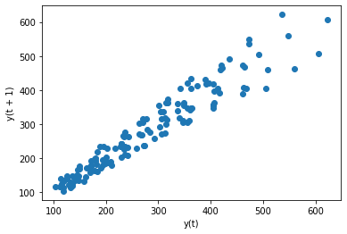

```python
lag_plot(df1['Thousands of Passengers']);
```

This shows evidence of very strong autocorrelation

Let's look at a lag plot of the stationary data set (the births)

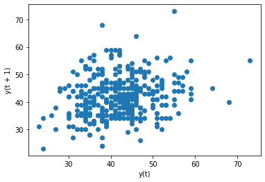

```python
lag_plot(df2['Births']);
```

## ACF Plots

Plotting the magnitude of the autocorrelations over the first few (20-40) lags can say a lot about a time series.

```python
from statsmodels.graphics.tsaplots import plot_acf,plot_pacf
```

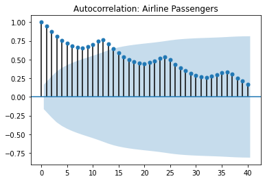

```python
# Now let's plot the autocorrelation at different lags
title = 'Autocorrelation: Airline Passengers'
lags = 40
plot_acf(df1,title=title,lags=lags);
```

There is clearly signs os seasonality in the data.

The shaded region is a 95% confidence interval. Which means that those points (those lags) outside the blue shaded area are more like to be correlated with the current year. While the higher the lag, the less likely is that there is signiciant correlation

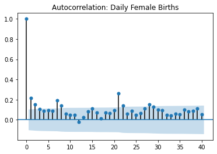

```python
title = 'Autocorrelation: Daily Female Births'
lags = 40
plot_acf(df2,title=title,lags=lags);
```

# Autoregressive Model

In a moving average model as we saw with Holt-Winters, we forecast the variable of interest using a linear combination of predictors. In our example we forecasted numbers of airline passengers in thousands based on a set of level, trend and seasonal predictors.

In an autoregression model, we forecast using a linear combination of *past values* of the variable. The term *autoregression* describes a regression of the variable against itself. An autoregression is run against a set of *lagged values* of order $p$.

### $y_{t} = c + \phi_{1}y_{t-1} + \phi_{2}y_{t-2} + \dots + \phi_{p}y_{t-p} + \varepsilon_{t}$

where $c$ is a constant, $\phi_{1}$ and $\phi_{2}$ are lag coefficients up to order $p$, and $\varepsilon_{t}$ is white noise.

For example, an **AR(1)** model would follow the formula

$y_{t} = c + \phi_{1}y_{t-1} + \varepsilon_{t}$

whereas an **AR(2)** model would follow the formula

$y_{t} = c + \phi_{1}y_{t-1} + \phi_{2}y_{t-2} + \varepsilon_{t}$

and so on.

Note that the lag coeffients are usually less than one, as we usually restrict autoregressive models to stationary data.  
Specifically, for an **AR(1)** model: $-1 \lt \phi_1 \lt 1$  
and for an **AR(2)** model: $-1 \lt \phi_2 \lt 1, \ \phi_1 + \phi_2 \lt 1, \ \phi_2 - \phi_1 \lt 1$

Models **AR(3)** and higher become mathematically very complex. Fortunately statsmodels does all the heavy lifting for us.

### Related Functions:

```
ar_model.AR(endog[, dates, freq, missing])  Autoregressive AR(p) model

ar_model.ARResults(model, params[, …])      Class to hold results from fitting an AR model
```

### For Further Reading:

**[Forecasting: Principles and Practice](https://otexts.com/fpp2/AR.html)** Autoregressive models  
**[Wikipedia](https://en.wikipedia.org/wiki/Autoregressive_model)** Autoregressive model

## Perform standard imports and load datasets

For this exercise we'll look at monthly U.S. population estimates in thousands from January 2011 to December 2018 (96 records, 8 years of data). Population includes resident population plus armed forces overseas. The monthly estimate is the average of estimates for the first of the month and the first of the following month. Source: https://fred.stlouisfed.org/series/POPTHM

```python
# Load specific forecasting tools
from statsmodels.tsa.ar_model import AR,ARResults

# Load the U.S. Population dataset
df = pd.read_csv('./original/TSA_COURSE_NOTEBOOKS/Data/uspopulation.csv',index_col='DATE',parse_dates=True)
df.index.freq = 'MS'
```

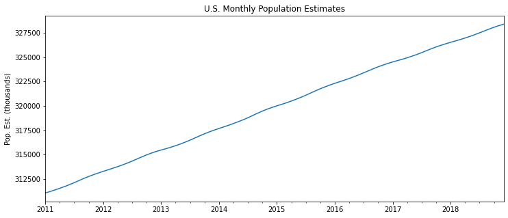

```python
title='U.S. Monthly Population Estimates'
ylabel='Pop. Est. (thousands)'
xlabel='' # we don't really need a label here

ax = df['PopEst'].plot(figsize=(12,5),title=title);
ax.autoscale(axis='x',tight=True)
ax.set(xlabel=xlabel, ylabel=ylabel);
```

## Split the data into train/test sets

The goal in this section is to:

- Split known data into a training set of records on which to fit the model
- Use the remaining records for testing, to evaluate the model
- Fit the model again on the *full* set of records
- Predict a future set of values using the model

As a general rule you should set the length of your test set equal to your intended forecast size. That is, for a monthly dataset you might want to forecast out one more year. Therefore your test set should be one year long.

**NOTE:** For many training and testing applications we would use the `train_test_split()` function available from Python's [scikit-learn](https://scikit-learn.org/stable/) library. This won't work here as `train_test_split()` takes *random samples* of data from the population.

Using the previous month to predict is not perfect, but still we get an acceptable result

```python
# Set one year for testing
train = df.iloc[:84]
test = df.iloc[84:]
```

```
Lag: 1
Coefficients:
const        284.913797
L1.PopEst      0.999686
dtype: float64
```

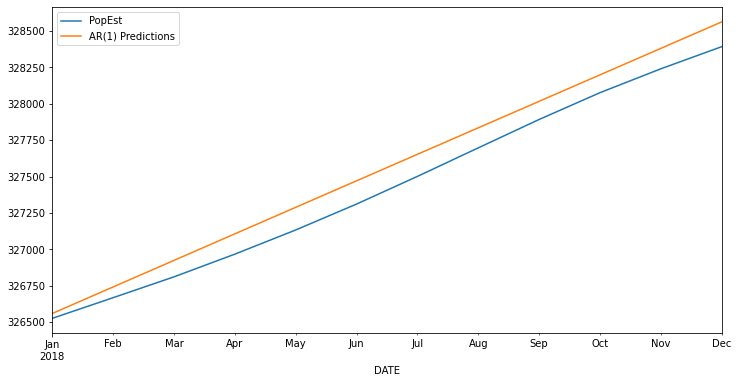

```python
model = AR(train['PopEst'])
AR1fit = model.fit(maxlag=1)
print(f'Lag: {AR1fit.k_ar}')
print(f'Coefficients:\n{AR1fit.params}')

# This is the general format for obtaining predictions
start=len(train)
end=len(train)+len(test)-1
predictions1 = AR1fit.predict(start=start, end=end, dynamic=False).rename('AR(1) Predictions')

test['PopEst'].plot(legend=True)
predictions1.plot(legend=True,figsize=(12,6));
```

### AR(2)

```
Lag: 2
Coefficients:
const        137.368305
L1.PopEst      1.853490
L2.PopEst     -0.853836
dtype: float64
```

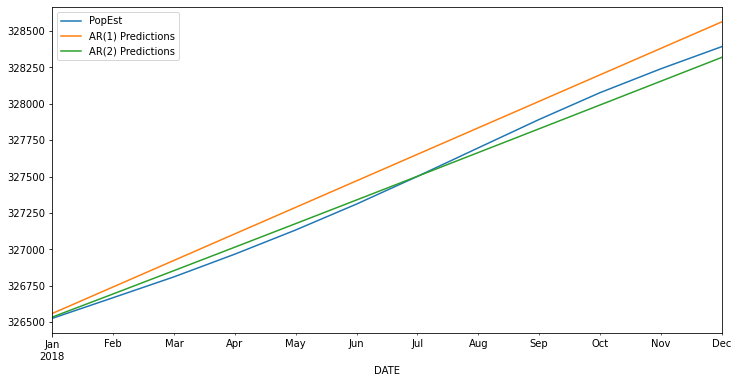

```python
# Recall that our model was already created above based on the training set
model2 = AR(train['PopEst'])
AR2fit = model2.fit(maxlag=2)
print(f'Lag: {AR2fit.k_ar}')
print(f'Coefficients:\n{AR2fit.params}')

start=len(train)
end=len(train)+len(test)-1
predictions2 = AR2fit.predict(start=start, end=end, dynamic=False).rename('AR(2) Predictions')

test['PopEst'].plot(legend=True)
predictions1.plot(legend=True)
predictions2.plot(legend=True,figsize=(12,6));
```

How do we actually find the best number of lags? We can optimize for "p" (number of lags)

If we leave the maxlg empty, statsmodels tries to find the optimal value.

```
Lag: 11
Coefficients:
const         96.143523
L1.PopEst      2.298626
L2.PopEst     -2.027441
L3.PopEst      1.356878
L4.PopEst     -1.171630
L5.PopEst      0.816723
L6.PopEst     -0.699990
L7.PopEst      0.727004
L8.PopEst     -0.354790
L9.PopEst      0.241036
L10.PopEst    -0.179865
L11.PopEst    -0.006819
dtype: float64
```

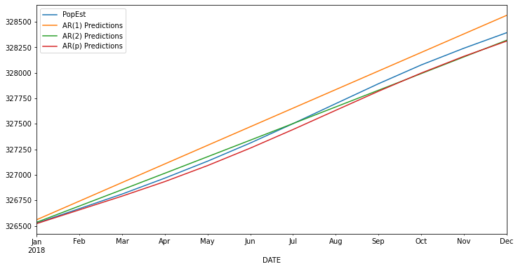

```python
modelp = AR(train['PopEst'])

ARfit = modelp.fit()
print(f'Lag: {ARfit.k_ar}')
print(f'Coefficients:\n{ARfit.params}')

predictionsp = ARfit.predict(start=start, end=end, dynamic=False).rename('AR(p) Predictions')

test['PopEst'].plot(legend=True)
predictions1.plot(legend=True)
predictions2.plot(legend=True)
predictionsp.plot(legend=True,figsize=(12,6));
```

But we can see that it actually has similar results as AR(2)

What we can do is to change the criterion that statsmodels uses to determine p. We will use the t-stat criterion

```
Lag: 8
Coefficients:
const        82.309677
L1.PopEst     2.437997
L2.PopEst    -2.302100
L3.PopEst     1.565427
L4.PopEst    -1.431211
L5.PopEst     1.125022
L6.PopEst    -0.919494
L7.PopEst     0.963694
L8.PopEst    -0.439511
dtype: float64
```

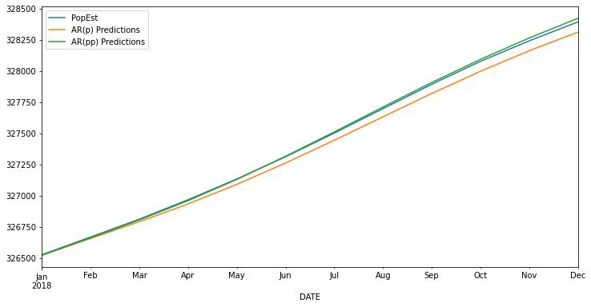

```python
modelpp = AR(train['PopEst'])

ARfit = modelpp.fit(ic='t-stat')
print(f'Lag: {ARfit.k_ar}')
print(f'Coefficients:\n{ARfit.params}')

predictionspp = ARfit.predict(start=start, end=end, dynamic=False).rename('AR(pp) Predictions')

test['PopEst'].plot(legend=True)
predictionsp.plot(legend=True)
predictionspp.plot(legend=True,figsize=(12,6));
```

That looks much better. But let's look at the mean squared error to see which one has a lowe error

```python
preds = [predictions1, predictions2, predictionsp, predictionspp]
labels = ['AR(1)','AR(2)','AR(p)', 'AR(pp)']
for i in range(len(preds)):
    error = mean_squared_error(test['PopEst'],preds[i])
    print(f'{labels[i]} MSE was :{error}')
```

```
AR(1) MSE was :17449.714238785422
AR(2) MSE was :2713.258528140898
AR(p) MSE was :3206.162817657509
AR(pp) MSE was :186.97397472611956
```

The last model, which used the t-stat as criterion is the one with the lower MSE

## Forecasting

Now we're ready to train our best model on the greatest amount of data, and fit it to future dates. Using the last model

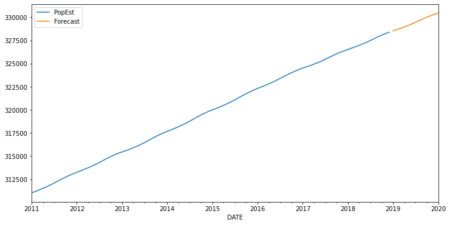

```python
# First, retrain the model on the full dataset
model = AR(df['PopEst'])

# Next, fit the model
ARfit = model.fit(ic='t-stat')

# Make predictions
fcast = ARfit.predict(start=len(df), end=len(df)+12, dynamic=False).rename('Forecast')

# Plot the results
df['PopEst'].plot(legend=True)
fcast.plot(legend=True,figsize=(12,6));
```

# Descriptive Statistics and Tests

In upcoming sections we'll talk about different forecasting models like ARMA, ARIMA, Seasonal ARIMA and others. Each model addresses a different type of time series. For this reason, in order to select an appropriate model we need to know something about the data.

In this section we'll learn how to determine if a time series is *stationary*, if it's *independent*, and if two series demonstrate *correlation* and/or *causality*.

- Goals
  - Be able to perform Augmented Dickey Fuller Test
  - Kwiatkowski-Phillips-Schmidt-Shin test for stationarity.
  - Calculate the BDS test statistic for independence of a time series
  - Return’s Ljung-Box Q Statistic
  - four tests for granger non-causality of 2 timeseries (maybe do this tests on two airline stocks against each other, or gas price versus airline stock/travel costs)

### Related Functions:

```
stattools.ccovf(x, y[, unbiased, demean])  crosscovariance for 1D

stattools.ccf(x, y[, unbiased])            cross-correlation function for 1d

stattools.periodogram(X)                   Returns the periodogram for the natural frequency of X


stattools.adfuller(x[, maxlag, regression, …])  Augmented Dickey-Fuller unit root test

stattools.kpss(x[, regression, lags, store])    Kwiatkowski-Phillips-Schmidt-Shin test for stationarity.

stattools.coint(y0, y1[, trend, method, …])     Test for no-cointegration of a univariate equation

stattools.bds(x[, max_dim, epsilon, distance])  Calculate the BDS test statistic for independence of a time series

stattools.q_stat(x, nobs[, type])               Returns Ljung-Box Q Statistic

stattools.grangercausalitytests(x, maxlag[, …]) Four tests for granger non-causality of 2 timeseries

stattools.levinson_durbin(s[, nlags, isacov])   Levinson-Durbin recursion for autoregressive processes


stattools.eval_measures.mse(x1, x2, axis=0)      mean squared error

stattools.eval_measures.rmse(x1, x2, axis=0)     root mean squared error

stattools.eval_measures.meanabs(x1, x2, axis=0)  mean absolute error
```

### For Further Reading:

**[Wikipedia:](https://en.wikipedia.org/wiki/Augmented_Dickey%E2%80%93Fuller_test)** Augmented Dickey–Fuller test  
**[Forecasting: Principles and Practice:](https://otexts.com/fpp2/accuracy.html)** Evaluating forecast accuracy

```python
# Ignore harmless warnings
import warnings
warnings.filterwarnings("ignore")

# Load a seasonal dataset
df1 = pd.read_csv('./original/TSA_COURSE_NOTEBOOKS/Data/airline_passengers.csv',index_col='Month',parse_dates=True)
df1.index.freq = 'MS'

# Load a nonseasonal dataset
df2 = pd.read_csv('./original/TSA_COURSE_NOTEBOOKS/Data/DailyTotalFemaleBirths.csv',index_col='Date',parse_dates=True)
df2.index.freq = 'D'

from statsmodels.tsa.stattools import ccovf,ccf,periodogram

from statsmodels.tsa.stattools import adfuller,kpss,coint,bds,q_stat,grangercausalitytests,levinson_durbin

from statsmodels.tools.eval_measures import mse, rmse, meanabs
```

# Tests for Stationarity

A time series is *stationary* if the mean and variance are fixed between any two equidistant points. That is, no matter where you take your observations, the results should be the same. A times series that shows seasonality is *not* stationary.

A test for stationarity usually involves a [unit root](https://en.wikipedia.org/wiki/Unit_root_test) hypothesis test, where the null hypothesis $H_0$ is that the series is *nonstationary*, and contains a unit root. The alternate hypothesis $H_1$ supports stationarity. The augmented Dickey-Fuller Test is one such test.

## Augmented Dickey-Fuller Test

To determine whether a series is stationary we can use the [augmented Dickey-Fuller Test](https://en.wikipedia.org/wiki/Augmented_Dickey-Fuller_test). In this test the null hypothesis states that $\phi = 1$ (this is also called a unit test). The test returns several statistics we'll see in a moment. Our focus is on the p-value. A small p-value ($p<0.05$) indicates strong evidence against the null hypothesis.

To demonstrate, we'll use a dataset we know is *not* stationary, the airline_passenger dataset. First, let's plot the data along with a 12-month rolling mean and standard deviation:

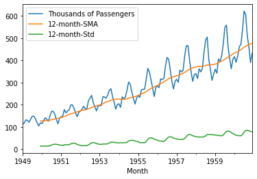

```python
df1['12-month-SMA'] = df1['Thousands of Passengers'].rolling(window=12).mean()
df1['12-month-Std'] = df1['Thousands of Passengers'].rolling(window=12).std()

df1[['Thousands of Passengers','12-month-SMA','12-month-Std']].plot();
```

Not only is this dataset seasonal with a clear upward trend, the standard deviation increases over time as well.

```python
print('Augmented Dickey-Fuller Test on Airline Data')
# Note that autolag = AIC, Akaike Information Criteria method
dftest = adfuller(df1['Thousands of Passengers'],autolag='AIC')
dftest
```

```
Augmented Dickey-Fuller Test on Airline Data
```

```
(0.8153688792060465,
 0.991880243437641,
 13,
 130,
 {'1%': -3.4816817173418295,
  '5%': -2.8840418343195267,
  '10%': -2.578770059171598},
 996.692930839019)
```

To understand what those values mean, you can also check more information with the help() function

```python
help(adfuller)
```

```
Help on function adfuller in module statsmodels.tsa.stattools:

adfuller(x, maxlag=None, regression='c', autolag='AIC', store=False, regresults=False)
    Augmented Dickey-Fuller unit root test.

    The Augmented Dickey-Fuller test can be used to test for a unit root in a
    univariate process in the presence of serial correlation.

    Parameters
    ----------
    x : array_like, 1d
        The data series to test.
    maxlag : int
        Maximum lag which is included in test, default 12*(nobs/100)^{1/4}.
    regression : {'c','ct','ctt','nc'}
        Constant and trend order to include in regression.

        * 'c' : constant only (default).
        * 'ct' : constant and trend.
        * 'ctt' : constant, and linear and quadratic trend.
        * 'nc' : no constant, no trend.

    autolag : {'AIC', 'BIC', 't-stat', None}
        Method to use when automatically determining the lag.

        * if None, then maxlag lags are used.
        * if 'AIC' (default) or 'BIC', then the number of lags is chosen
          to minimize the corresponding information criterion.
        * 't-stat' based choice of maxlag.  Starts with maxlag and drops a
          lag until the t-statistic on the last lag length is significant
          using a 5%-sized test.
    store : bool
        If True, then a result instance is returned additionally to
        the adf statistic. Default is False.
    regresults : bool, optional
        If True, the full regression results are returned. Default is False.

    Returns
    -------
    adf : float
```

[output cut: 31 more lines]

```
    .. [1] W. Green.  "Econometric Analysis," 5th ed., Pearson, 2003.

    .. [2] Hamilton, J.D.  "Time Series Analysis".  Princeton, 1994.

    .. [3] MacKinnon, J.G. 1994.  "Approximate asymptotic distribution functions for
        unit-root and cointegration tests.  `Journal of Business and Economic
        Statistics` 12, 167-76.

    .. [4] MacKinnon, J.G. 2010. "Critical Values for Cointegration Tests."  Queen's
        University, Dept of Economics, Working Papers.  Available at
        http://ideas.repec.org/p/qed/wpaper/1227.html

    Examples
    --------
    See example notebook
```

Since this is a bit annoying, we can customize it for our own use

```python
print('Augmented Dickey-Fuller Test on Airline Data')

dfout = pd.Series(dftest[0:4],index=['ADF test statistic','p-value','# lags used','# observations'])

for key,val in dftest[4].items():
    dfout[f'critical value ({key})']=val
print(dfout)
```

```
Augmented Dickey-Fuller Test on Airline Data
ADF test statistic        0.815369
p-value                   0.991880
# lags used              13.000000
# observations          130.000000
critical value (1%)      -3.481682
critical value (5%)      -2.884042
critical value (10%)     -2.578770
dtype: float64
```

Here we have a very high p-value at 0.99, which provides weak evidence against the null hypothesis, and so we *fail to reject* the null hypothesis, and decide that our dataset is not stationary.  
Note: in statistics we don't "accept" a null hypothesis - nothing is ever truly proven - we just fail to reject it.  
Now let's apply the ADF test to stationary data with the Daily Total Female Births dataset.

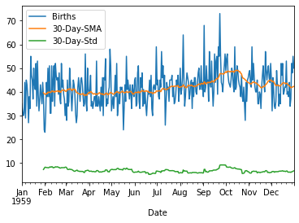

```python
df2['30-Day-SMA'] = df2['Births'].rolling(window=30).mean()
df2['30-Day-Std'] = df2['Births'].rolling(window=30).std()

df2[['Births','30-Day-SMA','30-Day-Std']].plot();
```

```python
print('Augmented Dickey-Fuller Test on Daily Female Births')
dftest = adfuller(df2['Births'],autolag='AIC')
dfout = pd.Series(dftest[0:4],index=['ADF test statistic','p-value','# lags used','# observations'])

for key,val in dftest[4].items():
    dfout[f'critical value ({key})']=val
print(dfout)
```

```
Augmented Dickey-Fuller Test on Daily Female Births
ADF test statistic       -4.808291
p-value                   0.000052
# lags used               6.000000
# observations          358.000000
critical value (1%)      -3.448749
critical value (5%)      -2.869647
critical value (10%)     -2.571089
dtype: float64
```

In this case our p-value is very low at 0.000052, and we do reject the null hypothesis. This dataset appears to have no unit root, and is stationary.

### Function for running the augmented Dickey-Fuller test

Since we'll use it frequently in the upcoming forecasts, let's define a function we can copy into future notebooks for running the augmented Dickey-Fuller test. Remember that we'll still have to import `adfuller` at the top of our notebook.

```python
from statsmodels.tsa.stattools import adfuller

def adf_test(series,title=''):
    """
    Pass in a time series and an optional title, returns an ADF report
    """
    print(f'Augmented Dickey-Fuller Test: {title}')
    result = adfuller(series.dropna(),autolag='AIC') # .dropna() handles differenced data

    labels = ['ADF test statistic','p-value','# lags used','# observations']
    out = pd.Series(result[0:4],index=labels)

    for key,val in result[4].items():
        out[f'critical value ({key})']=val

    print(out.to_string())          # .to_string() removes the line "dtype: float64"

    if result[1] <= 0.05:
        print("Strong evidence against the null hypothesis")
        print("Reject the null hypothesis")
        print("Data has no unit root and is stationary")
    else:
        print("Weak evidence against the null hypothesis")
        print("Fail to reject the null hypothesis")
        print("Data has a unit root and is non-stationary")
```

Let's run this function:

```python
adf_test(df1['Thousands of Passengers'])
```

```
Augmented Dickey-Fuller Test:
ADF test statistic        0.815369
p-value                   0.991880
# lags used              13.000000
# observations          130.000000
critical value (1%)      -3.481682
critical value (5%)      -2.884042
critical value (10%)     -2.578770
Weak evidence against the null hypothesis
Fail to reject the null hypothesis
Data has a unit root and is non-stationary
```

```python
adf_test(df2['Births'])
```

```
Augmented Dickey-Fuller Test:
ADF test statistic       -4.808291
p-value                   0.000052
# lags used               6.000000
# observations          358.000000
critical value (1%)      -3.448749
critical value (5%)      -2.869647
critical value (10%)     -2.571089
Strong evidence against the null hypothesis
Reject the null hypothesis
Data has no unit root and is stationary
```

### Granger Causality Tests

The Granger Cauality test tells us wether a series can be considered to be able to forecast another series. It will test it with various tests such as F-test and chi2-test

```python
df3 = pd.read_csv('./original/TSA_COURSE_NOTEBOOKS/Data/samples.csv',index_col=0, parse_dates=True)
df3.index.freq = 'MS'
df3.head()
```

```python
grangercausalitytests(df3[['a','c']],maxlag=3)
```

```
Granger Causality
number of lags (no zero) 1
ssr based F test:         F=0.1292  , p=0.7199  , df_denom=116, df_num=1
ssr based chi2 test:   chi2=0.1325  , p=0.7158  , df=1
likelihood ratio test: chi2=0.1325  , p=0.7159  , df=1
parameter F test:         F=0.1292  , p=0.7199  , df_denom=116, df_num=1

Granger Causality
number of lags (no zero) 2
ssr based F test:         F=0.8111  , p=0.4469  , df_denom=113, df_num=2
ssr based chi2 test:   chi2=1.6940  , p=0.4287  , df=2
likelihood ratio test: chi2=1.6820  , p=0.4313  , df=2
parameter F test:         F=0.8111  , p=0.4469  , df_denom=113, df_num=2

Granger Causality
number of lags (no zero) 3
ssr based F test:         F=0.4467  , p=0.7201  , df_denom=110, df_num=3
ssr based chi2 test:   chi2=1.4255  , p=0.6996  , df=3
likelihood ratio test: chi2=1.4169  , p=0.7016  , df=3
parameter F test:         F=0.4467  , p=0.7201  , df_denom=110, df_num=3
```

```
{1: ({'ssr_ftest': (0.12918575915661892, 0.7199312293830932, 116.0, 1),
   'ssr_chi2test': (0.13252677016929013, 0.715826449244265, 1),
   'lrtest': (0.13245302934637948, 0.7159020901722554, 1),
   'params_ftest': (0.12918575915736052, 0.7199312293823164, 116.0, 1.0)},
  [<statsmodels.regression.linear_model.RegressionResultsWrapper at 0x7f4edac562b0>,
   <statsmodels.regression.linear_model.RegressionResultsWrapper at 0x7f4edac56470>,
   array([[0., 1., 0.]])]),
 2: ({'ssr_ftest': (0.8111078932183546, 0.44693552581960305, 113.0, 2),
   'ssr_chi2test': (1.6939952460135548, 0.42870012105264843, 2),
   'lrtest': (1.6819509736778855, 0.43128960083084733, 2),
   'params_ftest': (0.8111078932163238, 0.4469355258204989, 113.0, 2.0)},
  [<statsmodels.regression.linear_model.RegressionResultsWrapper at 0x7f4edac56c18>,
   <statsmodels.regression.linear_model.RegressionResultsWrapper at 0x7f4edac56eb8>,
   array([[0., 0., 1., 0., 0.],
          [0., 0., 0., 1., 0.]])]),
 3: ({'ssr_ftest': (0.44673882003616905, 0.7200959797468032, 110.0, 3),
   'ssr_chi2test': (1.425502962115412, 0.6995677345603015, 3),
   'lrtest': (1.4168888483621913, 0.7015807104329939, 3),
   'params_ftest': (0.44673882005686966, 0.7200959797322368, 110.0, 3.0)},
  [<statsmodels.regression.linear_model.RegressionResultsWrapper at 0x7f4edac567f0>,
   <statsmodels.regression.linear_model.RegressionResultsWrapper at 0x7f4edac56cc0>,
   array([[0., 0., 0., 1., 0., 0., 0.],
          [0., 0., 0., 0., 1., 0., 0.],
          [0., 0., 0., 0., 0., 1., 0.]])])}
```

We need to interpret de p-values and since all of them are >0.05, we can say there is no time-causality in the time series

# Evaluating forecast accuracy

Two calculations related to linear regression are [**mean squared error**](https://en.wikipedia.org/wiki/Mean_squared_error) (MSE) and [**root mean squared error**](https://en.wikipedia.org/wiki/Root-mean-square_deviation) (RMSE)

The formula for the mean squared error is  
$MSE = {\frac 1 L} \sum\limits_{l=1}^L (y_{T+l} - \hat y_{T+l})^2$  
where $T$ is the last observation period and $l$ is the lag point up to $L$ number of test observations.

The formula for the root mean squared error is  
$RMSE = \sqrt{MSE} = \sqrt{{\frac 1 L} \sum\limits_{l=1}^L (y_{T+l} - \hat y_{T+l})^2}$

The advantage of the RMSE is that it is expressed in the same units as the data.

A method similar to the RMSE is the [**mean absolute error**](https://en.wikipedia.org/wiki/Mean_absolute_error) (MAE) which is the mean of the magnitudes of the error, given as

$MAE = {\frac 1 L} \sum\limits_{l=1}^L \mid{y_{T+l}} - \hat y_{T+l}\mid$

A forecast method that minimizes the MAE will lead to forecasts of the median, while minimizing the RMSE will lead to forecasts of the mean.

let's create some random data

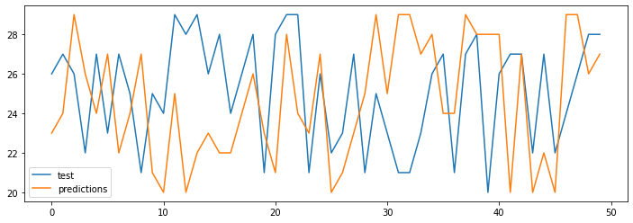

```python
np.random.seed(42)
df = pd.DataFrame(np.random.randint(20,30,(50,2)),columns=['test','predictions'])
df.plot(figsize=(12,4));
```

```python
df.head()
```

|  | test | predictions |
| --- | --- | --- |
| 0 | 26 | 23 |
| 1 | 27 | 24 |
| 2 | 26 | 29 |
| 3 | 22 | 26 |
| 4 | 27 | 24 |

```python
from statsmodels.tools.eval_measures import mse,rmse,meanabs
```

Let's use the most used metric for evaluating prediction accuracy

```python
rmse(df['test'],df['predictions'])
```

```
4.125530268947253
```

```python
df = pd.read_csv('./original/TSA_COURSE_NOTEBOOKS/Data/airline_passengers.csv',index_col='Month',parse_dates=True)
df.index.freq = 'MS'
```

let's take the data set and check monthly data

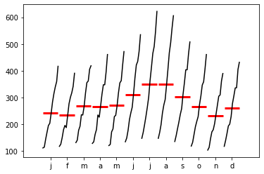

```python
from statsmodels.graphics.tsaplots import month_plot, quarter_plot

month_plot(df['Thousands of Passengers']);
```

This displays the range of values and their means (from the whole data series).

To check the quarter data, we will use:

```python
dfq = df["Thousands of Passengers"].resample(rule='Q').mean()
```

# Choosing ARIMA Orders

- Goals
  - Understand PDQ terms for ARIMA (slides)
  - Understand how to choose orders manually from ACF and PACF
  - Understand how to use automatic order selection techniques using the functions below

- **AR(p)** Autoregression - a regression model that utilizes the dependent relationship between a current observation and observations over a previous period.
- **I(d)** Integration - uses differencing of observations (subtracting an observation from an observation at the previous time step) in order to make the time series stationary. In other words how many times we need to difference the data to get it stationary so the AR and MA components can work.
- **MA(q)** Moving Average - a model that uses the dependency between an observation and a residual error from a moving average model applied to lagged observations.It indicates that the regressions error is a linear combination of error terms. We will set up another regression model that focuses on the residual term between a moving average and the real values

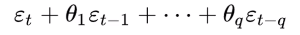

### Related Functions:

```
pmdarima.auto_arima(y[,start_p,d,start_q, …])   Returns the optimal order for an ARIMA model


Optional Function (see note below):

stattools.arma_order_select_ic(y[, max_ar, …])  Returns information criteria for many ARMA models

x13.x13_arima_select_order(endog[, …])          Perform automatic seasonal ARIMA order identification using x12/x13 ARIMA
```

```python
# Load a non-stationary dataset
df1 = pd.read_csv('./original/TSA_COURSE_NOTEBOOKS/Data/airline_passengers.csv',index_col='Month',parse_dates=True)
df1.index.freq = 'MS'

# Load a stationary dataset
df2 = pd.read_csv('./original/TSA_COURSE_NOTEBOOKS/Data/DailyTotalFemaleBirths.csv',index_col='Date',parse_dates=True)
df2.index.freq = 'D'
```

```python
from pmdarima import auto_arima

# Ignore harmless warnings
import warnings
warnings.filterwarnings("ignore")
```

```python
help(auto_arima)
```

```
Help on function auto_arima in module pmdarima.arima.auto:

auto_arima(y, exogenous=None, start_p=2, d=None, start_q=2, max_p=5, max_d=2, max_q=5, start_P=1, D=None, start_Q=1, max_P=2, max_D=1, max_Q=2, max_order=5, m=1, seasonal=True, stationary=False, information_criterion='aic', alpha=0.05, test='kpss', seasonal_test='ocsb', stepwise=True, n_jobs=1, star…
    Automatically discover the optimal order for an ARIMA model.

    The auto-ARIMA process seeks to identify the most optimal
    parameters for an ``ARIMA`` model, settling on a single fitted ARIMA model.
    This process is based on the commonly-used R function,
    ``forecast::auto.arima`` [3].

    Auto-ARIMA works by conducting differencing tests (i.e.,
    Kwiatkowski–Phillips–Schmidt–Shin, Augmented Dickey-Fuller or
    Phillips–Perron) to determine the order of differencing, ``d``, and then
    fitting models within ranges of defined ``start_p``, ``max_p``,
    ``start_q``, ``max_q`` ranges. If the ``seasonal`` optional is enabled,
    auto-ARIMA also seeks to identify the optimal ``P`` and ``Q`` hyper-
    parameters after conducting the Canova-Hansen to determine the optimal
    order of seasonal differencing, ``D``.

    In order to find the best model, auto-ARIMA optimizes for a given
    ``information_criterion``, one of ('aic', 'aicc', 'bic', 'hqic', 'oob')
    (Akaike Information Criterion, Corrected Akaike Information Criterion,
    Bayesian Information Criterion, Hannan-Quinn Information Criterion, or
    "out of bag"--for validation scoring--respectively) and returns the ARIMA
    which minimizes the value.

    Note that due to stationarity issues, auto-ARIMA might not find a
    suitable model that will converge. If this is the case, a ``ValueError``
    will be thrown suggesting stationarity-inducing measures be taken prior
    to re-fitting or that a new range of ``order`` values be selected. Non-
    stepwise (i.e., essentially a grid search) selection can be slow,
    especially for seasonal data. Stepwise algorithm is outlined in Hyndman and
    Khandakar (2008).

    Parameters
    ----------
    y : array-like or iterable, shape=(n_samples,)
        The time-series to which to fit the ``ARIMA`` estimator. This may
        either be a Pandas ``Series`` object (statsmodels can internally
        use the dates in the index), or a numpy array. This should be a
```

[output cut: 228 more lines]

```

    See Also
    --------
    :func:`pmdarima.arima.ARIMA`

    Notes
    -----
    * Fitting with `stepwise=False` can prove slower, especially when
      `seasonal=True`.

    References
    ----------
    .. [1] https://wikipedia.org/wiki/Autoregressive_integrated_moving_average
    .. [2] R's auto-arima source code: https://github.com/robjhyndman/forecast/blob/master/R/arima.R
    .. [3] R's auto-arima documentation: https://www.rdocumentation.org/packages/forecast
```

Auto_arima, based on the AIC, will give you the mest combination of p,d,q parameters

```python
auto_arima(df2['Births'])
```

```
ARIMA(maxiter=50, method='lbfgs', order=(1, 1, 1), out_of_sample_size=0,
      scoring='mse', scoring_args=None, seasonal_order=(0, 0, 0, 0),
      start_params=None, suppress_warnings=False, trend=None,
      with_intercept=True)
```

We specify we want the model to try from 0 to 6 p and from 0 to 3

```python
stepwise_fit = auto_arima(df2['Births'], start_p=0, start_q=0, max_p=6, max_q=3, seasonal=False, trace=True)
```

```
Performing stepwise search to minimize aic
Fit ARIMA(0,1,0)x(0,0,0,0) [intercept=True]; AIC=2650.760, BIC=2658.555, Time=0.026 seconds
Fit ARIMA(1,1,0)x(0,0,0,0) [intercept=True]; AIC=2565.234, BIC=2576.925, Time=0.060 seconds
Fit ARIMA(0,1,1)x(0,0,0,0) [intercept=True]; AIC=2463.584, BIC=2475.275, Time=0.128 seconds
Fit ARIMA(0,1,0)x(0,0,0,0) [intercept=False]; AIC=2648.768, BIC=2652.665, Time=0.015 seconds
Fit ARIMA(1,1,1)x(0,0,0,0) [intercept=True]; AIC=2460.154, BIC=2475.743, Time=0.217 seconds
Fit ARIMA(2,1,1)x(0,0,0,0) [intercept=True]; AIC=2461.271, BIC=2480.757, Time=0.312 seconds
Fit ARIMA(1,1,2)x(0,0,0,0) [intercept=True]; AIC=2460.810, BIC=2480.296, Time=1.050 seconds
Near non-invertible roots for order (1, 1, 2)(0, 0, 0, 0); setting score to inf (at least one inverse root too close to the border of the unit circle: 0.996)
Fit ARIMA(0,1,2)x(0,0,0,0) [intercept=True]; AIC=2460.722, BIC=2476.311, Time=0.445 seconds
Fit ARIMA(2,1,0)x(0,0,0,0) [intercept=True]; AIC=2536.154, BIC=2551.742, Time=0.182 seconds
Fit ARIMA(2,1,2)x(0,0,0,0) [intercept=True]; AIC=2463.066, BIC=2486.449, Time=1.325 seconds
Total fit time: 3.774 seconds
```

For our data, the best p,d,q parameters found are 1,1,1. Note that auto_arima did not try all of the parameters, since he/she realised that the AIC was actually not improving,so it stopped trying more combinations

This shows a recommended (p,d,q) ARIMA Order of (1,1,1), with no seasonal_order component.

We can see how this was determined by looking at the stepwise results. The recommended order is the one with the lowest [Akaike information criterion](https://en.wikipedia.org/wiki/Akaike_information_criterion) or AIC score. Note that the recommended model may *not* be the one with the closest fit. The AIC score takes complexity into account, and tries to identify the best *forecasting* model.

Let's have a look now at the description of the winner parameter-combination

**NOTE:** Harmless warnings should have been suppressed, but if you see an error citing unusual behavior you can suppress this message by passing `error_action='ignore'` into `auto_arima()`. Also, `auto_arima().summary()` provides a nicely formatted summary table.

```python
stepwise_fit.summary()
```

SARIMAX Results

| Dep. Variable: | y | No. Observations: | 365 |
| --- | --- | --- | --- |
| Model: | SARIMAX(1, 1, 1) | Log Likelihood | -1226.077 |
| Date: | Sun, 03 May 2020 | AIC | 2460.154 |
| Time: | 09:36:11 | BIC | 2475.743 |
| Sample: | 0 | HQIC | 2466.350 |
|  | - 365 |  |  |
| Covariance Type: | opg |  |  |

|  | coef | std err | z | P>\|z\| | [0.025 | 0.975] |
| --- | --- | --- | --- | --- | --- | --- |
| intercept | 0.0132 | 0.014 | 0.975 | 0.330 | -0.013 | 0.040 |
| ar.L1 | 0.1299 | 0.059 | 2.217 | 0.027 | 0.015 | 0.245 |
| ma.L1 | -0.9694 | 0.016 | -62.235 | 0.000 | -1.000 | -0.939 |
| sigma2 | 48.9989 | 3.432 | 14.279 | 0.000 | 42.273 | 55.725 |

| Ljung-Box (Q): | 36.69 | Jarque-Bera (JB): | 26.17 |
| --- | --- | --- | --- |
| Prob(Q): | 0.62 | Prob(JB): | 0.00 |
| Heteroskedasticity (H): | 0.97 | Skew: | 0.58 |
| Prob(H) (two-sided): | 0.85 | Kurtosis: | 3.62 |

Warnings:  
[1] Covariance matrix calculated using the outer product of gradients (complex-step).

Now let's look at the non-stationary, seasonal **Airline Passengers** dataset: Note that since we set seasonal=True, the model is also runing a SARIMA model

```python
# With Trace=True we can see the trace results of the parameter combination that the model is using
# m is the type of differencing, so if we difference on quarterly daya, we will set m=4, for monthly m=12, yearly m=1
stepwise_fit = auto_arima(df1['Thousands of Passengers'], start_p=1, start_q=1,
                          max_p=3, max_q=3, m=12,
                          start_P=0, seasonal=True,
                          d=None, D=1, trace=True,
                          error_action='ignore',   # we don't want to know if an order does not work
                          suppress_warnings=True,  # we don't want convergence warnings
                          stepwise=True)           # set to stepwise

stepwise_fit.summary()
```

```
Performing stepwise search to minimize aic
Fit ARIMA(1,1,1)x(0,1,1,12) [intercept=True]; AIC=1024.824, BIC=1039.200, Time=1.220 seconds
Fit ARIMA(0,1,0)x(0,1,0,12) [intercept=True]; AIC=1033.479, BIC=1039.229, Time=0.045 seconds
Fit ARIMA(1,1,0)x(1,1,0,12) [intercept=True]; AIC=1022.316, BIC=1033.817, Time=0.839 seconds
Fit ARIMA(0,1,1)x(0,1,1,12) [intercept=True]; AIC=1022.904, BIC=1034.405, Time=0.978 seconds
Fit ARIMA(0,1,0)x(0,1,0,12) [intercept=False]; AIC=1031.508, BIC=1034.383, Time=0.045 seconds
Fit ARIMA(1,1,0)x(0,1,0,12) [intercept=True]; AIC=1022.343, BIC=1030.968, Time=0.137 seconds
Fit ARIMA(1,1,0)x(2,1,0,12) [intercept=True]; AIC=1021.137, BIC=1035.513, Time=2.400 seconds
Fit ARIMA(1,1,0)x(2,1,1,12) [intercept=True]; AIC=1017.167, BIC=1034.418, Time=6.912 seconds
Near non-invertible roots for order (1, 1, 0)(2, 1, 1, 12); setting score to inf (at least one inverse root too close to the border of the unit circle: 0.998)
Fit ARIMA(1,1,0)x(1,1,1,12) [intercept=True]; AIC=1022.410, BIC=1036.786, Time=1.493 seconds
Fit ARIMA(0,1,0)x(2,1,0,12) [intercept=True]; AIC=1034.067, BIC=1045.568, Time=1.637 seconds
Fit ARIMA(2,1,0)x(2,1,0,12) [intercept=True]; AIC=1023.007, BIC=1040.258, Time=5.339 seconds
Fit ARIMA(1,1,1)x(2,1,0,12) [intercept=True]; AIC=1022.905, BIC=1040.156, Time=4.271 seconds
Fit ARIMA(0,1,1)x(2,1,0,12) [intercept=True]; AIC=1021.017, BIC=1035.393, Time=2.567 seconds
Fit ARIMA(0,1,1)x(1,1,0,12) [intercept=True]; AIC=1022.314, BIC=1033.815, Time=0.985 seconds
Fit ARIMA(0,1,1)x(2,1,1,12) [intercept=True]; AIC=1015.841, BIC=1033.092, Time=9.209 seconds
Near non-invertible roots for order (0, 1, 1)(2, 1, 1, 12); setting score to inf (at least one inverse root too close to the border of the unit circle: 0.998)
Fit ARIMA(0,1,1)x(1,1,1,12) [intercept=True]; AIC=1022.207, BIC=1036.583, Time=1.942 seconds
Fit ARIMA(0,1,2)x(2,1,0,12) [intercept=True]; AIC=1022.996, BIC=1040.247, Time=2.853 seconds
Fit ARIMA(1,1,2)x(2,1,0,12) [intercept=True]; AIC=1024.668, BIC=1044.795, Time=5.043 seconds
Total fit time: 47.950 seconds
```

SARIMAX Results

| Dep. Variable: | y | No. Observations: | 144 |
| --- | --- | --- | --- |
| Model: | SARIMAX(0, 1, 1)x(2, 1, 1, 12) | Log Likelihood | -501.920 |
| Date: | Sun, 03 May 2020 | AIC | 1015.841 |
| Time: | 09:42:20 | BIC | 1033.092 |
| Sample: | 0 | HQIC | 1022.851 |
|  | - 144 |  |  |
| Covariance Type: | opg |  |  |

|  | coef | std err | z | P>\|z\| | [0.025 | 0.975] |
| --- | --- | --- | --- | --- | --- | --- |
| intercept | 0.0003 | 0.033 | 0.010 | 0.992 | -0.064 | 0.064 |
| ma.L1 | -0.4237 | 0.069 | -6.177 | 0.000 | -0.558 | -0.289 |
| ar.S.L12 | 0.6676 | 0.161 | 4.149 | 0.000 | 0.352 | 0.983 |
| ar.S.L24 | 0.3310 | 0.095 | 3.480 | 0.001 | 0.145 | 0.517 |
| ma.S.L12 | -0.9748 | 1.252 | -0.779 | 0.436 | -3.428 | 1.478 |
| sigma2 | 110.8423 | 115.690 | 0.958 | 0.338 | -115.906 | 337.591 |

| Ljung-Box (Q): | 53.05 | Jarque-Bera (JB): | 7.56 |
| --- | --- | --- | --- |
| Prob(Q): | 0.08 | Prob(JB): | 0.02 |
| Heteroskedasticity (H): | 2.82 | Skew: | 0.10 |
| Prob(H) (two-sided): | 0.00 | Kurtosis: | 4.16 |

Warnings:  
[1] Covariance matrix calculated using the outer product of gradients (complex-step).

The winner is a SARIMA (0,1,1)x(2,1,12) (p,d,q)x(P,D,Q,M). We will talk about SARIMA later

In the table you can see the coefficients for each of the AR & MA lags

# ARMA(p,q) and ARIMA(p,d,q)

# Autoregressive Moving Averages

This section covers *Autoregressive Moving Averages* (ARMA) and *Autoregressive Integrated Moving Averages* (ARIMA).

Recall that an **AR(1)** model follows the formula

$y_{t} = c + \phi_{1}y_{t-1} + \varepsilon_{t}$

while an **MA(1)** model follows the formula

$y_{t} = \mu + \theta_{1}\varepsilon_{t-1} + \varepsilon_{t}$

where $c$ is a constant, $\mu$ is the expectation of $y_{t}$ (often assumed to be zero), $\phi_1$ (phi-sub-one) is the AR lag coefficient, $\theta_1$ (theta-sub-one) is the MA lag coefficient, and $\varepsilon$ (epsilon) is white noise.

An **ARMA(1,1)** model therefore follows

$y_{t} = c + \phi_{1}y_{t-1} + \theta_{1}\varepsilon_{t-1} + \varepsilon_{t}$

ARMA models can be used on stationary datasets.

For non-stationary datasets with a trend component, ARIMA models apply a differencing coefficient as well.

### Related Functions:

```
arima_model.ARMA(endog, order[, exog, …])     Autoregressive Moving Average ARMA(p,q) model


arima_model.ARMAResults(model, params[, …])   Class to hold results from fitting an ARMA model


arima_model.ARIMA(endog, order[, exog, …])    Autoregressive Integrated Moving Average ARIMA(p,d,q) model


arima_model.ARIMAResults(model, params[, …])  Class to hold results from fitting an ARIMA model


kalmanf.kalmanfilter.KalmanFilter             Kalman Filter code intended for use with the ARMA model
```

### For Further Reading:

**[Wikipedia](https://en.wikipedia.org/wiki/Autoregressive%E2%80%93moving-average_model)** Autoregressive–moving-average model  
**[Forecasting: Principles and Practice](https://otexts.com/fpp2/non-seasonal-arima.html)** Non-seasonal ARIMA models

## Autoregressive Moving Average - ARMA(p,q)

In this first section we'll look at a stationary dataset, determine (p,q) orders, and run a forecasting ARMA model fit to the data. In practice it's rare to find stationary data with no trend or seasonal component, but the first four months of the *Daily Total Female Births* dataset should work for our purposes.

### Plot the source data

```python
# Load specific forecasting tools
from statsmodels.tsa.arima_model import ARMA,ARMAResults,ARIMA,ARIMAResults
from statsmodels.graphics.tsaplots import plot_acf,plot_pacf # for determining (p,q) orders
from pmdarima import auto_arima # for determining ARIMA orders

# Ignore harmless warnings
import warnings
warnings.filterwarnings("ignore")

# Load datasets
df1 = pd.read_csv('./original/TSA_COURSE_NOTEBOOKS/Data/DailyTotalFemaleBirths.csv',index_col='Date',parse_dates=True)
df1.index.freq = 'D'
df1 = df1[:120]  # we only want the first four months

df2 = pd.read_csv('./original/TSA_COURSE_NOTEBOOKS/Data/TradeInventories.csv',index_col='Date',parse_dates=True)
df2.index.freq='MS'
```

```python
# this function was created previously (control f adf_test)
adf_test(df1["Births"])
```

```
Augmented Dickey-Fuller Test:
ADF test statistic     -9.855384e+00
p-value                 4.373545e-17
# lags used             0.000000e+00
# observations          1.190000e+02
critical value (1%)    -3.486535e+00
critical value (5%)    -2.886151e+00
critical value (10%)   -2.579896e+00
Strong evidence against the null hypothesis
Reject the null hypothesis
Data has no unit root and is stationary
```

### Determine the (p,q) ARMA Orders using `pmdarima.auto_arima`

This tool should give just $p$ and $q$ value recommendations for this dataset.

```python
auto_arima(df1["Births"],seasonal=False).summary()
```

SARIMAX Results

| Dep. Variable: | y | No. Observations: | 120 |
| --- | --- | --- | --- |
| Model: | SARIMAX | Log Likelihood | -409.745 |
| Date: | Sun, 03 May 2020 | AIC | 823.489 |
| Time: | 10:20:24 | BIC | 829.064 |
| Sample: | 0 | HQIC | 825.753 |
|  | - 120 |  |  |
| Covariance Type: | opg |  |  |

|  | coef | std err | z | P>\|z\| | [0.025 | 0.975] |
| --- | --- | --- | --- | --- | --- | --- |
| intercept | 39.7833 | 0.687 | 57.896 | 0.000 | 38.437 | 41.130 |
| sigma2 | 54.1197 | 8.319 | 6.506 | 0.000 | 37.815 | 70.424 |

| Ljung-Box (Q): | 44.41 | Jarque-Bera (JB): | 2.69 |
| --- | --- | --- | --- |
| Prob(Q): | 0.29 | Prob(JB): | 0.26 |
| Heteroskedasticity (H): | 0.80 | Skew: | 0.26 |
| Prob(H) (two-sided): | 0.48 | Kurtosis: | 2.48 |

Warnings:  
[1] Covariance matrix calculated using the outer product of gradients (complex-step).

### Split the data into train/test sets

As a general rule you should set the length of your test set equal to your intended forecast size. For this dataset we'll attempt a 1-month forecast.

```python
# Set one month for testing
train = df1.iloc[:90]
test = df1.iloc[90:]
```

### Fit an ARMA(p,q) Model

If you want you can run `help(ARMA)` to learn what incoming arguments are available/expected, and what's being returned.

```python
model = ARMA(train['Births'],order=(2,2))
results = model.fit()
results.summary()
```

ARMA Model Results

| Dep. Variable: | Births | No. Observations: | 90 |
| --- | --- | --- | --- |
| Model: | ARMA(2, 2) | Log Likelihood | -307.905 |
| Method: | css-mle | S.D. of innovations | 7.405 |
| Date: | Sun, 03 May 2020 | AIC | 627.809 |
| Time: | 10:21:56 | BIC | 642.808 |
| Sample: | 01-01-1959 | HQIC | 633.858 |
|  | - 03-31-1959 |  |  |

|  | coef | std err | z | P>\|z\| | [0.025 | 0.975] |
| --- | --- | --- | --- | --- | --- | --- |
| const | 39.7549 | 0.912 | 43.607 | 0.000 | 37.968 | 41.542 |
| ar.L1.Births | -0.1850 | 1.087 | -0.170 | 0.865 | -2.315 | 1.945 |
| ar.L2.Births | 0.4352 | 0.644 | 0.675 | 0.500 | -0.828 | 1.698 |
| ma.L1.Births | 0.2777 | 1.097 | 0.253 | 0.800 | -1.872 | 2.427 |
| ma.L2.Births | -0.3999 | 0.679 | -0.589 | 0.556 | -1.730 | 0.930 |

Roots

|  | Real | Imaginary | Modulus | Frequency |
| --- | --- | --- | --- | --- |
| AR.1 | -1.3181 | +0.0000j | 1.3181 | 0.5000 |
| AR.2 | 1.7434 | +0.0000j | 1.7434 | 0.0000 |
| MA.1 | -1.2718 | +0.0000j | 1.2718 | 0.5000 |
| MA.2 | 1.9662 | +0.0000j | 1.9662 | 0.0000 |

### Obtain a month's worth of predicted values

```python
start=len(train)
end=len(train)+len(test)-1
predictions = results.predict(start=start, end=end).rename('ARMA(2,2) Predictions')
```

### Plot predictions against known values

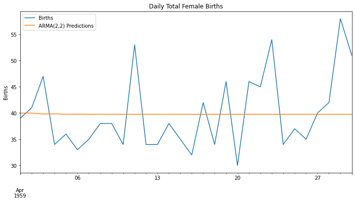

```python
title = 'Daily Total Female Births'
ylabel='Births'
xlabel='' # we don't really need a label here

ax = test['Births'].plot(legend=True,figsize=(12,6),title=title)
predictions.plot(legend=True)
ax.autoscale(axis='x',tight=True)
ax.set(xlabel=xlabel, ylabel=ylabel);
```

The orange line is the predicted values, which even though it looks like it is a very bad prediction, it makes completely sense since ARMA shows the average value. The model is not able to predict the noise, but is able to predict the average value.

In fact if we calculate the average value of test and predictions, they have the same average value:

```python
test.mean()
```

```
Births    39.833333
dtype: float64
```

```python
predictions.mean()
```

```
39.7774288668336
```

Now let's work on the ARIMA mode,so we will ad the I component into the ARMA model:

## Autoregressive Integrated Moving Average - ARIMA(p,d,q)

The steps are the same as for ARMA(p,q), except that we'll apply a differencing component to make the dataset stationary.  
First let's take a look at the *Real Manufacturing and Trade Inventories* dataset.

### Plot the Source Data

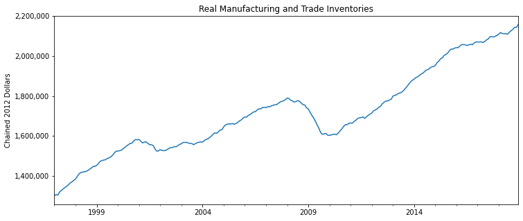

```python
# HERE'S A TRICK TO ADD COMMAS TO Y-AXIS TICK VALUES
import matplotlib.ticker as ticker

formatter = ticker.StrMethodFormatter('{x:,.0f}')

title = 'Real Manufacturing and Trade Inventories'
ylabel='Chained 2012 Dollars'
xlabel='' # we don't really need a label here

ax = df2['Inventories'].plot(figsize=(12,5),title=title)
ax.autoscale(axis='x',tight=True)
ax.set(xlabel=xlabel, ylabel=ylabel)
ax.yaxis.set_major_formatter(formatter);
```

### Run an ETS Decomposition

We probably won't learn a lot from it, but it never hurts to run an ETS Decomposition plot.

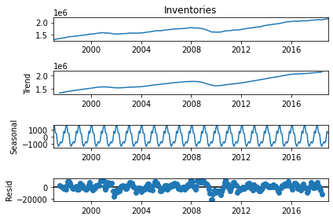

```python
from statsmodels.tsa.seasonal import seasonal_decompose

result = seasonal_decompose(df2['Inventories'], model='additive')  # model='add' also works
result.plot();
```

Here we see that the seasonal component does not contribute significantly to the behavior of the series.

### Use `pmdarima.auto_arima` to determine ARIMA Orders

So for the purpose of this code, we will ignore the seasonal component (otherwise we should use SARIMA, instead of ARIMA)

```python
auto_arima(df2['Inventories'],seasonal=False).summary()
```

SARIMAX Results

| Dep. Variable: | y | No. Observations: | 264 |
| --- | --- | --- | --- |
| Model: | SARIMAX(0, 1, 0) | Log Likelihood | -2672.018 |
| Date: | Sun, 03 May 2020 | AIC | 5348.037 |
| Time: | 10:33:03 | BIC | 5355.181 |
| Sample: | 0 | HQIC | 5350.908 |
|  | - 264 |  |  |
| Covariance Type: | opg |  |  |

|  | coef | std err | z | P>\|z\| | [0.025 | 0.975] |
| --- | --- | --- | --- | --- | --- | --- |
| intercept | 3258.3802 | 470.991 | 6.918 | 0.000 | 2335.255 | 4181.506 |
| sigma2 | 3.91e+07 | 2.95e+06 | 13.250 | 0.000 | 3.33e+07 | 4.49e+07 |

| Ljung-Box (Q): | 455.75 | Jarque-Bera (JB): | 100.74 |
| --- | --- | --- | --- |
| Prob(Q): | 0.00 | Prob(JB): | 0.00 |
| Heteroskedasticity (H): | 0.86 | Skew: | -1.15 |
| Prob(H) (two-sided): | 0.48 | Kurtosis: | 4.98 |

Warnings:  
[1] Covariance matrix calculated using the outer product of gradients (complex-step).

This suggests that we should fit an SARIMAX(0,1,0) model to best forecast future values of the series. Before we train the model, let's look at augmented Dickey-Fuller Test, and the ACF/PACF plots to see if they agree. These steps are optional, and we would likely skip them in practice.

```python
from statsmodels.tsa.statespace.tools import diff
df2['d1'] = diff(df2['Inventories'],k_diff=1)

# Equivalent to:
# df1['d1'] = df1['Inventories'] - df1['Inventories'].shift(1)

adf_test(df2['d1'],'Real Manufacturing and Trade Inventories')
```

```
Augmented Dickey-Fuller Test: Real Manufacturing and Trade Inventories
ADF test statistic       -3.412249
p-value                   0.010548
# lags used               4.000000
# observations          258.000000
critical value (1%)      -3.455953
critical value (5%)      -2.872809
critical value (10%)     -2.572775
Strong evidence against the null hypothesis
Reject the null hypothesis
Data has no unit root and is stationary
```

This confirms that we reached stationarity after the first difference.

### Run the ACF and PACF plots

A **PACF Plot** can reveal recommended AR(p) orders, and an **ACF Plot** can do the same for MA(q) orders.  
Alternatively, we can compare the stepwise [Akaike Information Criterion (AIC)](https://en.wikipedia.org/wiki/Akaike_information_criterion) values across a set of different (p,q) combinations to choose the best combination.

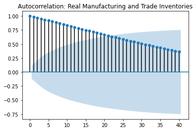

```python
title = 'Autocorrelation: Real Manufacturing and Trade Inventories'
lags = 40
plot_acf(df2['Inventories'],title=title,lags=lags);
```

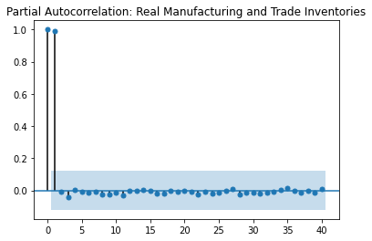

```python
title = 'Partial Autocorrelation: Real Manufacturing and Trade Inventories'
lags = 40
plot_pacf(df2['Inventories'],title=title,lags=lags);
```

This tells us that the AR component should be more important than MA. From the [Duke University Statistical Forecasting site](https://people.duke.edu/~rnau/411arim3.htm):

> *If the PACF displays a sharp cutoff while the ACF decays more slowly (i.e., has significant spikes at higher lags), we say that the stationarized series displays an "AR signature," meaning that the autocorrelation pattern can be explained more easily by adding AR terms than by adding MA terms.*

Let's take a look at `pmdarima.auto_arima` done stepwise to see if having $p$ and $q$ terms the same still makes sense:

```python
stepwise_fit = auto_arima(df2['Inventories'], start_p=0, start_q=0,
                          max_p=2, max_q=2, m=12,
                          seasonal=False,
                          d=None, trace=True,
                          error_action='ignore',   # we don't want to know if an order does not work
                          suppress_warnings=True,  # we don't want convergence warnings
                          stepwise=True)           # set to stepwise

stepwise_fit.summary()
```

```
Performing stepwise search to minimize aic
Fit ARIMA(0,1,0)x(0,0,0,0) [intercept=True]; AIC=5348.037, BIC=5355.181, Time=0.043 seconds
Fit ARIMA(1,1,0)x(0,0,0,0) [intercept=True]; AIC=5399.843, BIC=5410.560, Time=0.106 seconds
Fit ARIMA(0,1,1)x(0,0,0,0) [intercept=True]; AIC=5350.241, BIC=5360.957, Time=0.098 seconds
Fit ARIMA(0,1,0)x(0,0,0,0) [intercept=False]; AIC=5409.217, BIC=5412.789, Time=0.032 seconds
Fit ARIMA(1,1,1)x(0,0,0,0) [intercept=True]; AIC=5378.835, BIC=5393.124, Time=0.503 seconds
Total fit time: 0.790 seconds
```

SARIMAX Results

| Dep. Variable: | y | No. Observations: | 264 |
| --- | --- | --- | --- |
| Model: | SARIMAX(0, 1, 0) | Log Likelihood | -2672.018 |
| Date: | Sun, 03 May 2020 | AIC | 5348.037 |
| Time: | 10:39:27 | BIC | 5355.181 |
| Sample: | 0 | HQIC | 5350.908 |
|  | - 264 |  |  |
| Covariance Type: | opg |  |  |

|  | coef | std err | z | P>\|z\| | [0.025 | 0.975] |
| --- | --- | --- | --- | --- | --- | --- |
| intercept | 3258.3802 | 470.991 | 6.918 | 0.000 | 2335.255 | 4181.506 |
| sigma2 | 3.91e+07 | 2.95e+06 | 13.250 | 0.000 | 3.33e+07 | 4.49e+07 |

| Ljung-Box (Q): | 455.75 | Jarque-Bera (JB): | 100.74 |
| --- | --- | --- | --- |
| Prob(Q): | 0.00 | Prob(JB): | 0.00 |
| Heteroskedasticity (H): | 0.86 | Skew: | -1.15 |
| Prob(H) (two-sided): | 0.48 | Kurtosis: | 4.98 |

Warnings:  
[1] Covariance matrix calculated using the outer product of gradients (complex-step).

### Split the data into train/test sets

```python
len(df2)
```

```
264
```

```python
# Set one year for testing
train = df2.iloc[:252]
test = df2.iloc[252:]
```

### Fit an ARIMA(1,1,1) Model

```python
model = ARIMA(train['Inventories'],order=(1,1,1))
results = model.fit()
results.summary()
```

ARIMA Model Results

| Dep. Variable: | D.Inventories | No. Observations: | 251 |
| --- | --- | --- | --- |
| Model: | ARIMA(1, 1, 1) | Log Likelihood | -2486.394 |
| Method: | css-mle | S.D. of innovations | 4845.007 |
| Date: | Sun, 03 May 2020 | AIC | 4980.788 |
| Time: | 10:57:38 | BIC | 4994.890 |
| Sample: | 02-01-1997 | HQIC | 4986.463 |
|  | - 12-01-2017 |  |  |

|  | coef | std err | z | P>\|z\| | [0.025 | 0.975] |
| --- | --- | --- | --- | --- | --- | --- |
| const | 3235.7979 | 1344.940 | 2.406 | 0.016 | 599.764 | 5871.832 |
| ar.L1.D.Inventories | 0.9026 | 0.039 | 23.012 | 0.000 | 0.826 | 0.979 |
| ma.L1.D.Inventories | -0.5581 | 0.079 | -7.048 | 0.000 | -0.713 | -0.403 |

Roots

|  | Real | Imaginary | Modulus | Frequency |
| --- | --- | --- | --- | --- |
| AR.1 | 1.1080 | +0.0000j | 1.1080 | 0.0000 |
| MA.1 | 1.7917 | +0.0000j | 1.7917 | 0.0000 |

```python
# Obtain predicted values
start=len(train)
end=len(train)+len(test)-1
predictions = results.predict(start=start, end=end, dynamic=False, typ='levels').rename('ARIMA(1,1,1) Predictions')
```

Passing `dynamic=False` means that forecasts at each point are generated using the full history up to that point (all lagged values).

Passing `typ='levels'` predicts the levels of the original endogenous variables. If we'd used the default `typ='linear'` we would have seen linear predictions in terms of the differenced endogenous variables.

For more information on these arguments visit https://www.statsmodels.org/stable/generated/statsmodels.tsa.arima_model.ARIMAResults.predict.html

```python
# Compare predictions to expected values
for i in range(len(predictions)):
    print(f"predicted={predictions[i]:<11.10}, expected={test['Inventories'][i]}")
```

```
predicted=2107156.741, expected=2110158
predicted=2110545.923, expected=2118199
predicted=2113920.16 , expected=2112427
predicted=2117280.909, expected=2112276
predicted=2120629.483, expected=2111835
predicted=2123967.068, expected=2109298
predicted=2127294.736, expected=2119618
predicted=2130613.453, expected=2127170
predicted=2133924.091, expected=2134172
predicted=2137227.436, expected=2144639
predicted=2140524.201, expected=2143001
predicted=2143815.024, expected=2158115
```

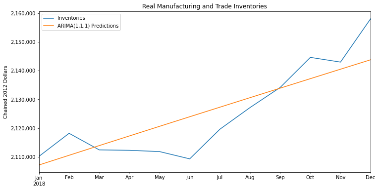

```python
# Plot predictions against known values
title = 'Real Manufacturing and Trade Inventories'
ylabel='Chained 2012 Dollars'
xlabel='' # we don't really need a label here

ax = test['Inventories'].plot(legend=True,figsize=(12,6),title=title)
predictions.plot(legend=True)
ax.autoscale(axis='x',tight=True)
ax.set(xlabel=xlabel, ylabel=ylabel)
ax.yaxis.set_major_formatter(formatter);
```

### Evaluate the Model

```python
from sklearn.metrics import mean_squared_error

error = mean_squared_error(test['Inventories'], predictions)
print(f'ARIMA(1,1,1) MSE Error: {error:11.10}')
```

```
ARIMA(1,1,1) MSE Error: 60315541.59
```

```python
from statsmodels.tools.eval_measures import rmse

error = rmse(test['Inventories'], predictions)
print(f'ARIMA(1,1,1) RMSE Error: {error:11.10}')
```

```
ARIMA(1,1,1) RMSE Error: 7766.308105
```

### Retrain the model on the full data, and forecast the future

```python
model = ARIMA(df2['Inventories'],order=(1,1,1))
results = model.fit()
fcast = results.predict(len(df2),len(df2)+11,typ='levels').rename('ARIMA(1,1,1) Forecast')
```

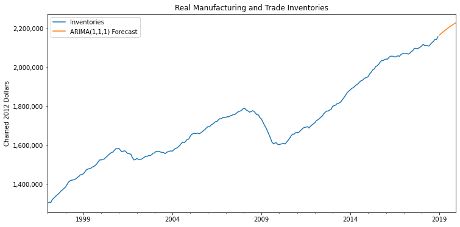

```python
# Plot predictions against known values
title = 'Real Manufacturing and Trade Inventories'
ylabel='Chained 2012 Dollars'
xlabel='' # we don't really need a label here

ax = df2['Inventories'].plot(legend=True,figsize=(12,6),title=title)
fcast.plot(legend=True)
ax.autoscale(axis='x',tight=True)
ax.set(xlabel=xlabel, ylabel=ylabel)
ax.yaxis.set_major_formatter(formatter);
```

# Seasonal Autoregressive Integrated Moving Averages

We have finally reached one of the most fascinating aspects of time series analysis: seasonality.

Where ARIMA accepts the parameters $(p,d,q)$, SARIMA accepts an *additional* set of parameters $(P,D,Q)m$ that specifically describe the seasonal components of the model. Here $P$, $D$ and $Q$ represent the seasonal regression, differencing and moving average coefficients, and $m$ represents the number of data points (rows) in each seasonal cycle.

**NOTE:** The statsmodels implementation of SARIMA is called SARIMAX. The “X” added to the name means that the function also supports *exogenous* regressor variables. We'll cover these in the next section.

### Related Functions:

```
sarimax.SARIMAX(endog[, exog, order, …])

sarimax.SARIMAXResults(model, params, …[, …])  Class to hold results from fitting a SARIMAX model.
```

### For Further Reading:

**[Statsmodels Tutorial:](https://www.statsmodels.org/stable/statespace.html)** Time Series Analysis by State Space Methods

## Perform standard imports and load datasets

```python
# Load specific forecasting tools
from statsmodels.tsa.statespace.sarimax import SARIMAX

from statsmodels.graphics.tsaplots import plot_acf,plot_pacf # for determining (p,q) orders
from statsmodels.tsa.seasonal import seasonal_decompose      # for ETS Plots
from pmdarima import auto_arima                              # for determining ARIMA orders

# Ignore harmless warnings
import warnings
warnings.filterwarnings("ignore")

# Load dataset
df = pd.read_csv('./original/TSA_COURSE_NOTEBOOKS/Data/co2_mm_mlo.csv')
```

```python
df.head()
```

We need to combine two integer columns (year and month) into a DatetimeIndex. We can do this by passing a dictionary into `pandas.to_datetime()` with year, month and day values.  
For more information visit https://pandas.pydata.org/pandas-docs/stable/reference/api/pandas.to_datetime.html

```python
# Add a "date" datetime column
df['date']=pd.to_datetime(dict(year=df['year'], month=df['month'], day=1))

#another way to merge dates is  pd.to_datetime({'year':df['year'],'month':df['month'],'day':1})


# Set "date" to be the index
df.set_index('date',inplace=True)
df.index.freq = 'MS'
df.head()
```

| date | year | month | decimal_date | average | interpolated |
| --- | --- | --- | --- | --- | --- |
| 1958-03-01 | 1958 | 3 | 1958.208 | 315.71 | 315.71 |
| 1958-04-01 | 1958 | 4 | 1958.292 | 317.45 | 317.45 |
| 1958-05-01 | 1958 | 5 | 1958.375 | 317.50 | 317.50 |
| 1958-06-01 | 1958 | 6 | 1958.458 | NaN | 317.10 |
| 1958-07-01 | 1958 | 7 | 1958.542 | 315.86 | 315.86 |

```python
df.info()
```

```
<class 'pandas.core.frame.DataFrame'>
DatetimeIndex: 729 entries, 1958-03-01 to 2018-11-01
Freq: MS
Data columns (total 5 columns):
 #   Column        Non-Null Count  Dtype
---  ------        --------------  -----
 0   year          729 non-null    int64
 1   month         729 non-null    int64
 2   decimal_date  729 non-null    float64
 3   average       722 non-null    float64
 4   interpolated  729 non-null    float64
dtypes: float64(3), int64(2)
memory usage: 34.2 KB
```

### Plot the source data

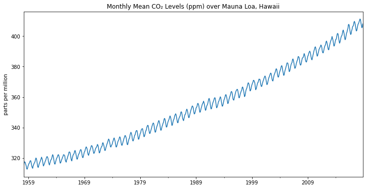

```python
title = 'Monthly Mean CO₂ Levels (ppm) over Mauna Loa, Hawaii'
ylabel='parts per million'
xlabel='' # we don't really need a label here

ax = df['interpolated'].plot(figsize=(12,6),title=title)
ax.autoscale(axis='x',tight=True)
ax.set(xlabel=xlabel, ylabel=ylabel);
```

### Run an ETS Decomposition

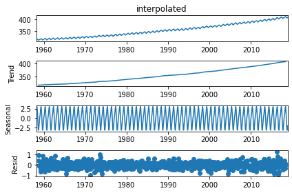

```python
result = seasonal_decompose(df['interpolated'], model='add')
result.plot();
```

Although small in scale compared to the overall values, there is a definite annual seasonality.

### Run `pmdarima.auto_arima` to obtain recommended orders

This may take awhile as there are a lot more combinations to evaluate.

```python
# For SARIMA Orders we set seasonal=True and pass in an m value
# since seasonality is yearl and we have monthly data then m=12
auto_arima(df['interpolated'],seasonal=True,m=12).summary()
```

SARIMAX Results

| Dep. Variable: | y | No. Observations: | 729 |
| --- | --- | --- | --- |
| Model: | SARIMAX(0, 1, 2)x(1, 0, [1], 12) | Log Likelihood | -208.275 |
| Date: | Sun, 03 May 2020 | AIC | 428.550 |
| Time: | 13:44:12 | BIC | 456.091 |
| Sample: | 0 | HQIC | 439.177 |
|  | - 729 |  |  |
| Covariance Type: | opg |  |  |

|  | coef | std err | z | P>\|z\| | [0.025 | 0.975] |
| --- | --- | --- | --- | --- | --- | --- |
| intercept | 0.0001 | 0.000 | 1.009 | 0.313 | -0.000 | 0.000 |
| ma.L1 | -0.3562 | 0.037 | -9.719 | 0.000 | -0.428 | -0.284 |
| ma.L2 | -0.0615 | 0.033 | -1.844 | 0.065 | -0.127 | 0.004 |
| ar.S.L12 | 0.9996 | 0.000 | 3048.169 | 0.000 | 0.999 | 1.000 |
| ma.S.L12 | -0.8654 | 0.022 | -40.083 | 0.000 | -0.908 | -0.823 |
| sigma2 | 0.0963 | 0.005 | 20.314 | 0.000 | 0.087 | 0.106 |

| Ljung-Box (Q): | 50.10 | Jarque-Bera (JB): | 4.37 |
| --- | --- | --- | --- |
| Prob(Q): | 0.13 | Prob(JB): | 0.11 |
| Heteroskedasticity (H): | 1.11 | Skew: | -0.02 |
| Prob(H) (two-sided): | 0.40 | Kurtosis: | 3.38 |

Warnings:  
[1] Covariance matrix calculated using the outer product of gradients (complex-step).